# PT-P2 Neural Network Training

This notebook follows the lecture section order and adapts the code to the PT-P2 dataset stored in Google Drive.

## Introduction: What this notebook is, how it's organized, and why

**How it's organized.** The notebook follows the assignment's Task 1-4 structure, and every experiment reuses the same 4-part cell pattern:

Task 1 (`EXP-01`) replicates the assignment's default baseline settings. Task 2 (`EXP-02`-`EXP-05`) deliberately induces underfitting, then overfitting, then tests regularization, then a custom config — each one isolating a specific lecture concept. Task 4 (`EXP-05A`-`EXP-05J`) is a **one-variable-at- a-time ablation chain**: each run changes exactly one lever off a shared baseline (`EXP-05C`, which combines the two things that helped independently — early stopping and expanded data) so that any change in the result can be attributed to one specific cause rather than a bundle of simultaneous changes.

**Why this structure.** The exercise's real goal isn't just to run Keras — it's to *outperform the PT-P1 no-code benchmark* (90.0% accuracy on clear phrasing, 33.3%→43.3% on sarcastic/ambiguous phrasing after refinement) while being able to explain *why* each configuration change helped or hurt, in terms of the three hyperparameter pillars and the bias/variance tradeoff the lecture covers. One-variable-at-a-time ablation is what makes those explanations defensible rather than guesswork: if two hyperparameters change at once and the result improves, there's no way to know which change actually mattered.

**What this cell does:** Mounts Google Drive (where the CSVs and saved loss-curve PNGs live) and imports every library used later in the notebook.

**How:**

- `drive.mount('/content/drive')` gives this Colab session read/write access to the `PT-P2 Neural Network Training` folder in Drive, so later cells can load `pt_p1_dataset.csv` and save loss-curve images there.
- `pandas`/`numpy` handle the CSV data and array math.
- `Sequential`, `Embedding`, `GlobalAveragePooling1D`, `Dense`, `Dropout` from `tensorflow.keras` are the exact building blocks used to construct every model in this notebook.
- `Adam`, `SGD` are the two optimizers Task 2/4 compare (Pillar 2: Optimization).
- `train_test_split` performs the 70/15/15 train/val/test partition the exercise requires.
- `f1_score`, `accuracy_score`, `precision_score`, `recall_score` compute the metrics the training log needs (`average='weighted'` is used later so metrics account for class support).
- `Counter` is used inside the custom tokenizer to count word frequencies when building the vocabulary.
- `matplotlib.pyplot` draws the loss curves.
- `np.random.seed(42)` / `tf.random.set_seed(42)` fix the random number generators up front.

**Why:** Every experiment cell later in the notebook re-applies these same two seed calls right before building its model. Doing it here *and* per-experiment means each run's weight initialization is controlled as tightly as TensorFlow allows, which matters because the "Random Seed" column in the experiment log is only meaningful if runs are actually reproducible enough to compare against each other.

## Load & Preprocess CSV Data

**What this cell does:** Loads the PT-P1 dataset, turns the raw text into fixed-length integer sequences a neural network can actually take as input, and splits everything into train/validation/test sets.

**How, line by line:**

- `CSV_FILEPATH` points at the same 332-row dataset used in PT-P1, so PT-P2's results are directly comparable to that benchmark.
- `MAX_LEN = 20` caps every input at 20 tokens (longer sentences get truncated, shorter ones padded) — Keras needs every input to be the same shape.
- `MAX_VOCAB_SIZE = 1000` caps how many distinct words get their own vocabulary slot.
- `build_vocab()` lower-cases and splits every sentence into words, counts frequency with `Counter`, and keeps only the most common `MAX_VOCAB_SIZE - 2` words — the `-2` reserves index 0 for a `<PAD>` token and index 1 for `<UNK>` (any word that didn't make the cut), so *every* possible word maps to *some* integer even if it's rare or unseen.
- `text_to_sequence()` converts one sentence into a list of vocabulary indices, then pads with zeros or truncates to exactly `MAX_LEN` tokens.
- `vocab = build_vocab(...)` / `encoded_texts = [...]` apply those two functions across the whole dataset, producing `X_data` (the numeric feature matrix) and `y_data` (the integer labels).
- `train_test_split` is called twice: first splits 70% train / 30% "temp", then splits that temp set 50/50 into validation and test — together giving the required 70%/15%/15% partition.

**Why:** This is the "feature extraction" step the lecture and PT-P1 report both point to — a neural network can't do math on raw words, so this cell is the translation layer that turns labeled text into numbers before any training can happen. The exact 70/15/15 split matches Slide 6 ("Dataset Partitioning and Preprocessing") and the assignment's Task 1 requirement, and keeping a strictly isolated test set (never touched during training or hyperparameter tuning) is what makes the final evaluation trustworthy rather than optimistic.

```
Dataset shape: (332, 3)
Columns: ['text', 'label', 'category']
Classes: 3
Train/Val/Test shapes: (232, 20) (50, 20) (50, 20)
```

## Hyperparameter Configuration & Keras Sequential Architecture

**What this cell does:** Defines the hyperparameter configuration for **EXP-01-KERAS-BASELINE** and builds the Keras model architecture from it (Pillar 1: Architecture).

**How:**

- `np.random.seed(42)` / `tf.random.set_seed(42)` are re-applied here (not just once at the top of the notebook) so this specific run's weight initialization starts from the same fixed point regardless of what earlier experiment cells already ran and consumed random state from.
- `CONFIG` bundles this run's hyperparameters: `embed_dim`=32 and `hidden_dim`=64 are Pillar 1 (Architecture); `learning_rate`=0.005, `batch_size`=32, `epochs`=15, `optimizer_type`="Adam" are Pillar 2 (Optimization); `dropout_rate`=0.1 is Pillar 3 (Regularization).
- `tf.keras.backend.clear_session()` wipes any model/graph left behind by a previous cell, so re-running cells out of order can't leak weights between experiments.
- `Sequential()` + `Input(shape=(MAX_LEN,))` declares the model and forces Keras to build it immediately, so `model.summary()` later shows real shapes instead of `?`.
- `Embedding(input_dim=len(vocab), output_dim=32, mask_zero=True)` turns each integer token into a learned 32-length vector; `mask_zero=True` tells later layers to ignore `<PAD>` positions.
- `GlobalAveragePooling1D()` averages those per-token vectors into one fixed-length vector per example — the automated feature-extraction step the lecture points to.
- `Dense(64, activation='relu')` is the hidden layer doing the actual pattern learning.
- `Dropout(0.1)` randomly zeroes hidden units during training to fight overfitting.
- `Dense(num_classes, activation='softmax')` outputs a probability over the 3 sentiment classes.

**Why:** This is the required Task 1 baseline run, using the assignment's exact default settings (embed 32, hidden 64, LR 0.005, batch 32, epochs 15, dropout 0.1). Its job is to see whether an out-of-the-box Keras model already beats the PT-P1 no-code benchmark before any tuning happens.

## Optimizer and Compilation & The Operational Loop (Fit & Evaluate)

**How:**

- The `if/else` on `CONFIG["optimizer_type"]` builds either an `Adam` or `SGD` optimizer object using this run's learning rate.
- `model.compile(loss='sparse_categorical_crossentropy', optimizer=opt, metrics=['accuracy'])` — sparse categorical cross-entropy is used because the labels are plain integers (0/1/2), not one-hot vectors; `accuracy` is tracked per epoch alongside loss.
- `model.summary()` prints the layer-by-layer shape/parameter table as a sanity check before training starts.
- `history = model.fit(X_train, y_train, validation_data=(X_val, y_val), epochs=..., batch_size=..., verbose=1)` — this call *is* the training loop from the lecture: each epoch runs Forward Pass → Loss Calculation → Backward Pass → Weight Update over every mini-batch, then evaluates once on the validation set.
- `val_preds_probs = model.predict(X_val)` → `np.argmax(..., axis=1)` converts the softmax probability vector for each example into a single predicted class (0, 1, or 2).
- `f1_score(y_val, val_preds, average='weighted')` (plus `precision_score`/`recall_score`, same `average='weighted'`) weights each class's contribution by how many examples it has — matching what the exercise deliverables table asks for ("Final Validation Weighted F1-Score").
- `val_loss = history.history['val_loss'][-1]` takes the final epoch's validation loss, since this run doesn't use early stopping and always trains the full fixed epoch count.
- The final `print(...)` writes one summary line the student copies into the Excel training log.

```
Model: "sequential"
```

```
┏━━━━━━━━━━━━━━━━━━━━━━━━━━━━━━━━━┳━━━━━━━━━━━━━━━━━━━━━━━━┳━━━━━━━━━━━━━━━┓
┃ Layer (type)                    ┃ Output Shape           ┃       Param # ┃
┡━━━━━━━━━━━━━━━━━━━━━━━━━━━━━━━━━╇━━━━━━━━━━━━━━━━━━━━━━━━╇━━━━━━━━━━━━━━━┩
│ embedding (Embedding)           │ (None, 20, 32)         │        32,000 │
├─────────────────────────────────┼────────────────────────┼───────────────┤
│ global_average_pooling1d        │ (None, 32)             │             0 │
│ (GlobalAveragePooling1D)        │                        │               │
├─────────────────────────────────┼────────────────────────┼───────────────┤
│ dense (Dense)                   │ (None, 64)             │         2,112 │
├─────────────────────────────────┼────────────────────────┼───────────────┤
│ dropout (Dropout)               │ (None, 64)             │             0 │
├─────────────────────────────────┼────────────────────────┼───────────────┤
│ dense_1 (Dense)                 │ (None, 3)              │           195 │
└─────────────────────────────────┴────────────────────────┴───────────────┘
```

```
 Total params: 34,307 (134.01 KB)
```

```
 Trainable params: 34,307 (134.01 KB)
```

```
 Non-trainable params: 0 (0.00 B)
```

```
--- Starting Training Run: EXP-01-KERAS-BASELINE ---
8/8 ━━━━━━━━━━━━━━━━━━━━ 2s 70ms/step - accuracy: 0.4181 - loss: 1.0939 - val_accuracy: 0.6000 - val_loss: 1.0760
8/8 ━━━━━━━━━━━━━━━━━━━━ 0s 24ms/step - accuracy: 0.8362 - loss: 1.0044 - val_accuracy: 0.7400 - val_loss: 0.9903
8/8 ━━━━━━━━━━━━━━━━━━━━ 0s 33ms/step - accuracy: 0.9440 - loss: 0.8088 - val_accuracy: 0.7800 - val_loss: 0.8342
8/8 ━━━━━━━━━━━━━━━━━━━━ 0s 33ms/step - accuracy: 0.9612 - loss: 0.5045 - val_accuracy: 0.7800 - val_loss: 0.6471
8/8 ━━━━━━━━━━━━━━━━━━━━ 0s 16ms/step - accuracy: 0.9871 - loss: 0.2111 - val_accuracy: 0.8000 - val_loss: 0.5248
8/8 ━━━━━━━━━━━━━━━━━━━━ 0s 17ms/step - accuracy: 0.9914 - loss: 0.0743 - val_accuracy: 0.8000 - val_loss: 0.5018
8/8 ━━━━━━━━━━━━━━━━━━━━ 0s 19ms/step - accuracy: 0.9957 - loss: 0.0313 - val_accuracy: 0.8000 - val_loss: 0.5279
8/8 ━━━━━━━━━━━━━━━━━━━━ 0s 18ms/step - accuracy: 1.0000 - loss: 0.0140 - val_accuracy: 0.7800 - val_loss: 0.5593
8/8 ━━━━━━━━━━━━━━━━━━━━ 0s 22ms/step - accuracy: 1.0000 - loss: 0.0061 - val_accuracy: 0.7600 - val_loss: 0.5852
8/8 ━━━━━━━━━━━━━━━━━━━━ 0s 18ms/step - accuracy: 1.0000 - loss: 0.0034 - val_accuracy: 0.7600 - val_loss: 0.6063
8/8 ━━━━━━━━━━━━━━━━━━━━ 0s 17ms/step - accuracy: 1.0000 - loss: 0.0029 - val_accuracy: 0.7800 - val_loss: 0.6253
8/8 ━━━━━━━━━━━━━━━━━━━━ 0s 24ms/step - accuracy: 1.0000 - loss: 0.0026 - val_accuracy: 0.7800 - val_loss: 0.6398
8/8 ━━━━━━━━━━━━━━━━━━━━ 0s 20ms/step - accuracy: 1.0000 - loss: 0.0019 - val_accuracy: 0.7800 - val_loss: 0.6503
8/8 ━━━━━━━━━━━━━━━━━━━━ 0s 14ms/step - accuracy: 1.0000 - loss: 0.0017 - val_accuracy: 0.7800 - val_loss: 0.6594
8/8 ━━━━━━━━━━━━━━━━━━━━ 0s 12ms/step - accuracy: 1.0000 - loss: 0.0013 - val_accuracy: 0.7800 - val_loss: 0.6684
2/2 ━━━━━━━━━━━━━━━━━━━━ 0s 76ms/step

=== EXP LOG ENTRY ===
ID: EXP-01-KERAS-BASELINE | LR: 0.005 | Hidden: 64 | Dropout: 0.1 | Final Val Loss: 0.6684 | Final Val F1: 0.7836 | Final Val Precision: 0.8040 | Final Val Recall: 0.7800
```

## Generate Loss Curves Chart

**How:**

- `train_losses`/`val_losses` are pulled straight from `history.history`, the per-epoch log Keras kept during `.fit()` in the previous cell.
- `epochs_range = range(1, CONFIG['epochs'] + 1)` — since this run doesn't use early stopping, the number of epochs plotted always matches the configured cap.
- Two lines are plotted on the same axes: training loss (blue, solid, circle markers) and validation loss (red, dashed, square markers) — putting both on one chart is what makes over/underfitting visually obvious, per the lecture's "Diagnosing Model Fit" slide (converging together = good fit, diverging = overfitting, both flat and high = underfitting).
- `plt.savefig(f'{SAVE_DIR}/{CONFIG["run_id"]}_loss_curve.png', ...)` writes a uniquely-named PNG for this run into the shared `loss_curves` Drive folder *before* `plt.show()` displays it inline, so every run's chart survives after the session ends.

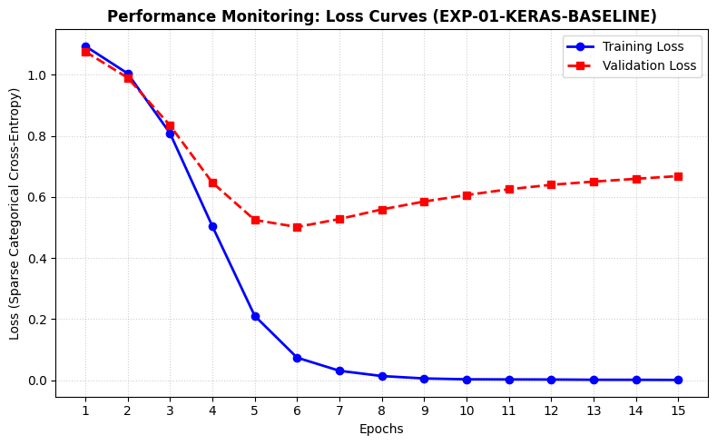

# Task 2: Systematic Experimentation & Outperforming PT-P1

Modify the HYPERPARAMETER CONFIGURATION to execute four (4) additional experiments (EXP-02 to EXP-05). The goal is to systematically iterate on the architecture and hyperparameters and observe if any model can exceed the PT-P1 baseline performance.

## EXP-02-UNDERFITTING: Low Capacity & Too Small LR (Induce Underfitting)

**What this cell does:** Defines the hyperparameter configuration for **EXP-02-UNDERFITTING** and builds the Keras model architecture from it (Pillar 1: Architecture).

**How:**

- `np.random.seed(42)` / `tf.random.set_seed(42)` are re-applied here (not just once at the top of the notebook) so this specific run's weight initialization starts from the same fixed point regardless of what earlier experiment cells already ran and consumed random state from.
- `CONFIG` bundles this run's hyperparameters: `embed_dim`=32 and `hidden_dim`=16 are Pillar 1 (Architecture); `learning_rate`=0.0001, `batch_size`=32, `epochs`=15, `optimizer_type`="Adam" are Pillar 2 (Optimization); `dropout_rate`=0.0 is Pillar 3 (Regularization).
- `tf.keras.backend.clear_session()` wipes any model/graph left behind by a previous cell, so re-running cells out of order can't leak weights between experiments.
- `Sequential()` + `Input(shape=(MAX_LEN,))` declares the model and forces Keras to build it immediately, so `model.summary()` later shows real shapes instead of `?`.
- `Embedding(input_dim=len(vocab), output_dim=32, mask_zero=True)` turns each integer token into a learned 32-length vector; `mask_zero=True` tells later layers to ignore `<PAD>` positions.
- `GlobalAveragePooling1D()` averages those per-token vectors into one fixed-length vector per example — the automated feature-extraction step the lecture points to.
- `Dense(16, activation='relu')` is the hidden layer doing the actual pattern learning.
- `Dropout(0.0)` randomly zeroes hidden units during training to fight overfitting.
- `Dense(num_classes, activation='softmax')` outputs a probability over the 3 sentiment classes.

**Why:** `hidden_dim` is dropped to 16 and `learning_rate` to 0.0001 on purpose — this is Task 2's “Low Capacity & Too Small LR (Induce Underfitting)” run. A hidden layer this small can't represent the sentiment patterns well, and a learning rate this small barely moves the weights each step, so the model should stay under-trained even after 15 epochs — the high-train-loss/high-val-loss signature the lecture describes for underfitting.

**What this cell does:** Builds the optimizer, compiles the model, prints its summary, trains it, and computes the validation metrics logged for **EXP-02-UNDERFITTING**.

**How:**

- The `if/else` on `CONFIG["optimizer_type"]` builds either an `Adam` or `SGD` optimizer object using this run's learning rate.
- `model.compile(loss='sparse_categorical_crossentropy', optimizer=opt, metrics=['accuracy'])` — sparse categorical cross-entropy is used because the labels are plain integers (0/1/2), not one-hot vectors; `accuracy` is tracked per epoch alongside loss.
- `model.summary()` prints the layer-by-layer shape/parameter table as a sanity check before training starts.
- `history = model.fit(X_train, y_train, validation_data=(X_val, y_val), epochs=..., batch_size=..., verbose=1)` — this call *is* the training loop from the lecture: each epoch runs Forward Pass → Loss Calculation → Backward Pass → Weight Update over every mini-batch, then evaluates once on the validation set.
- `val_preds_probs = model.predict(X_val)` → `np.argmax(..., axis=1)` converts the softmax probability vector for each example into a single predicted class (0, 1, or 2).
- `f1_score(y_val, val_preds, average='weighted')` (plus `precision_score`/`recall_score`, same `average='weighted'`) weights each class's contribution by how many examples it has — matching what the exercise deliverables table asks for ("Final Validation Weighted F1-Score").
- `val_loss = history.history['val_loss'][-1]` takes the final epoch's validation loss, since this run doesn't use early stopping and always trains the full fixed epoch count.
- The final `print(...)` writes one summary line the student copies into the Excel training log.

**Why:** This cell is where EXP-02-UNDERFITTING actually learns from data — the config/architecture cell above only sets the model up; this is what produces the val loss / F1 / precision / recall numbers that get compared against the PT-P1 benchmark and against every other run in the study.

```
Model: "sequential"
```

```
┏━━━━━━━━━━━━━━━━━━━━━━━━━━━━━━━━━┳━━━━━━━━━━━━━━━━━━━━━━━━┳━━━━━━━━━━━━━━━┓
┃ Layer (type)                    ┃ Output Shape           ┃       Param # ┃
┡━━━━━━━━━━━━━━━━━━━━━━━━━━━━━━━━━╇━━━━━━━━━━━━━━━━━━━━━━━━╇━━━━━━━━━━━━━━━┩
│ embedding (Embedding)           │ (None, 20, 32)         │        32,000 │
├─────────────────────────────────┼────────────────────────┼───────────────┤
│ global_average_pooling1d        │ (None, 32)             │             0 │
│ (GlobalAveragePooling1D)        │                        │               │
├─────────────────────────────────┼────────────────────────┼───────────────┤
│ dense (Dense)                   │ (None, 16)             │           528 │
├─────────────────────────────────┼────────────────────────┼───────────────┤
│ dropout (Dropout)               │ (None, 16)             │             0 │
├─────────────────────────────────┼────────────────────────┼───────────────┤
│ dense_1 (Dense)                 │ (None, 3)              │            51 │
└─────────────────────────────────┴────────────────────────┴───────────────┘
```

```
 Total params: 32,579 (127.26 KB)
```

```
 Trainable params: 32,579 (127.26 KB)
```

```
 Non-trainable params: 0 (0.00 B)
```

```
--- Starting Training Run: EXP-02-UNDERFITTING ---
8/8 ━━━━━━━━━━━━━━━━━━━━ 1s 38ms/step - accuracy: 0.3190 - loss: 1.0990 - val_accuracy: 0.4800 - val_loss: 1.0981
8/8 ━━━━━━━━━━━━━━━━━━━━ 0s 12ms/step - accuracy: 0.3793 - loss: 1.0981 - val_accuracy: 0.5000 - val_loss: 1.0978
8/8 ━━━━━━━━━━━━━━━━━━━━ 0s 11ms/step - accuracy: 0.4483 - loss: 1.0974 - val_accuracy: 0.5000 - val_loss: 1.0976
8/8 ━━━━━━━━━━━━━━━━━━━━ 0s 12ms/step - accuracy: 0.4828 - loss: 1.0967 - val_accuracy: 0.5600 - val_loss: 1.0973
8/8 ━━━━━━━━━━━━━━━━━━━━ 0s 11ms/step - accuracy: 0.5302 - loss: 1.0960 - val_accuracy: 0.5600 - val_loss: 1.0970
8/8 ━━━━━━━━━━━━━━━━━━━━ 0s 11ms/step - accuracy: 0.5647 - loss: 1.0953 - val_accuracy: 0.5600 - val_loss: 1.0967
8/8 ━━━━━━━━━━━━━━━━━━━━ 0s 11ms/step - accuracy: 0.5905 - loss: 1.0945 - val_accuracy: 0.5600 - val_loss: 1.0963
8/8 ━━━━━━━━━━━━━━━━━━━━ 0s 14ms/step - accuracy: 0.6078 - loss: 1.0937 - val_accuracy: 0.5600 - val_loss: 1.0960
8/8 ━━━━━━━━━━━━━━━━━━━━ 0s 12ms/step - accuracy: 0.6207 - loss: 1.0929 - val_accuracy: 0.5800 - val_loss: 1.0955
8/8 ━━━━━━━━━━━━━━━━━━━━ 0s 11ms/step - accuracy: 0.6250 - loss: 1.0920 - val_accuracy: 0.5800 - val_loss: 1.0951
8/8 ━━━━━━━━━━━━━━━━━━━━ 0s 12ms/step - accuracy: 0.6293 - loss: 1.0911 - val_accuracy: 0.5600 - val_loss: 1.0946
8/8 ━━━━━━━━━━━━━━━━━━━━ 0s 11ms/step - accuracy: 0.6422 - loss: 1.0901 - val_accuracy: 0.5600 - val_loss: 1.0940
8/8 ━━━━━━━━━━━━━━━━━━━━ 0s 12ms/step - accuracy: 0.6466 - loss: 1.0891 - val_accuracy: 0.5600 - val_loss: 1.0934
8/8 ━━━━━━━━━━━━━━━━━━━━ 0s 11ms/step - accuracy: 0.6466 - loss: 1.0881 - val_accuracy: 0.5600 - val_loss: 1.0928
8/8 ━━━━━━━━━━━━━━━━━━━━ 0s 11ms/step - accuracy: 0.6552 - loss: 1.0869 - val_accuracy: 0.5600 - val_loss: 1.0922
2/2 ━━━━━━━━━━━━━━━━━━━━ 0s 73ms/step

=== EXP LOG ENTRY ===
ID: EXP-02-UNDERFITTING | LR: 0.0001 | Hidden: 16 | Dropout: 0.0 | Final Val Loss: 1.0922 | Final Val F1: 0.4579 | Final Val Precision: 0.4052 | Final Val Recall: 0.5600
```

**What this cell does:** Plots training loss vs. validation loss per epoch for **EXP-02-UNDERFITTING** and saves the figure to Drive.

**How:**

- `train_losses`/`val_losses` are pulled straight from `history.history`, the per-epoch log Keras kept during `.fit()` in the previous cell.
- `epochs_range = range(1, CONFIG['epochs'] + 1)` — since this run doesn't use early stopping, the number of epochs plotted always matches the configured cap.
- Two lines are plotted on the same axes: training loss (blue, solid, circle markers) and validation loss (red, dashed, square markers) — putting both on one chart is what makes over/underfitting visually obvious, per the lecture's "Diagnosing Model Fit" slide (converging together = good fit, diverging = overfitting, both flat and high = underfitting).
- `plt.savefig(f'{SAVE_DIR}/{CONFIG["run_id"]}_loss_curve.png', ...)` writes a uniquely-named PNG for this run into the shared `loss_curves` Drive folder *before* `plt.show()` displays it inline, so every run's chart survives after the session ends.

**Why:** Task 3 explicitly requires saving a copy of each experiment's loss curve for the report, and this is the artifact used to classify EXP-02-UNDERFITTING as underfitting, overfitting, or a good fit when writing up Discussion Question 2.

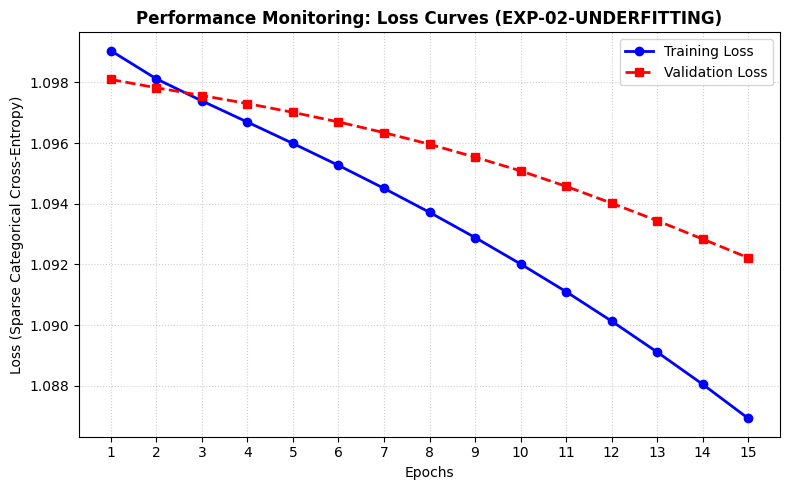

## EXP-03-OVERFITTING: High Capacity & No Regularization (Induce Overfitting)

**What this cell does:** Defines the hyperparameter configuration for **EXP-03-OVERFITTING** and builds the Keras model architecture from it (Pillar 1: Architecture).

**How:**

- `np.random.seed(42)` / `tf.random.set_seed(42)` are re-applied here (not just once at the top of the notebook) so this specific run's weight initialization starts from the same fixed point regardless of what earlier experiment cells already ran and consumed random state from.
- `CONFIG` bundles this run's hyperparameters: `embed_dim`=32 and `hidden_dim`=256 are Pillar 1 (Architecture); `learning_rate`=0.05, `batch_size`=32, `epochs`=15, `optimizer_type`="Adam" are Pillar 2 (Optimization); `dropout_rate`=0.0 is Pillar 3 (Regularization).
- `tf.keras.backend.clear_session()` wipes any model/graph left behind by a previous cell, so re-running cells out of order can't leak weights between experiments.
- `Sequential()` + `Input(shape=(MAX_LEN,))` declares the model and forces Keras to build it immediately, so `model.summary()` later shows real shapes instead of `?`.
- `Embedding(input_dim=len(vocab), output_dim=32, mask_zero=True)` turns each integer token into a learned 32-length vector; `mask_zero=True` tells later layers to ignore `<PAD>` positions.
- `GlobalAveragePooling1D()` averages those per-token vectors into one fixed-length vector per example — the automated feature-extraction step the lecture points to.
- `Dense(256, activation='relu')` is the hidden layer doing the actual pattern learning.
- `Dropout(0.0)` randomly zeroes hidden units during training to fight overfitting.
- `Dense(num_classes, activation='softmax')` outputs a probability over the 3 sentiment classes.

**Why:** `hidden_dim` is raised to 256, `learning_rate` to 0.05, and `dropout_rate` to 0 — deliberately maximizing capacity and optimization aggressiveness while removing the only regularization lever available, per Task 2's “High Capacity & No Regularization (Induce Overfitting)” spec. The model is expected to memorize the small training set almost immediately.

**What this cell does:** Builds the optimizer, compiles the model, prints its summary, trains it, and computes the validation metrics logged for **EXP-03-OVERFITTING**.

**How:**

- The `if/else` on `CONFIG["optimizer_type"]` builds either an `Adam` or `SGD` optimizer object using this run's learning rate.
- `model.compile(loss='sparse_categorical_crossentropy', optimizer=opt, metrics=['accuracy'])` — sparse categorical cross-entropy is used because the labels are plain integers (0/1/2), not one-hot vectors; `accuracy` is tracked per epoch alongside loss.
- `model.summary()` prints the layer-by-layer shape/parameter table as a sanity check before training starts.
- `history = model.fit(X_train, y_train, validation_data=(X_val, y_val), epochs=..., batch_size=..., verbose=1)` — this call *is* the training loop from the lecture: each epoch runs Forward Pass → Loss Calculation → Backward Pass → Weight Update over every mini-batch, then evaluates once on the validation set.
- `val_preds_probs = model.predict(X_val)` → `np.argmax(..., axis=1)` converts the softmax probability vector for each example into a single predicted class (0, 1, or 2).
- `f1_score(y_val, val_preds, average='weighted')` (plus `precision_score`/`recall_score`, same `average='weighted'`) weights each class's contribution by how many examples it has — matching what the exercise deliverables table asks for ("Final Validation Weighted F1-Score").
- `val_loss = history.history['val_loss'][-1]` takes the final epoch's validation loss, since this run doesn't use early stopping and always trains the full fixed epoch count.
- The final `print(...)` writes one summary line the student copies into the Excel training log.

**Why:** This cell is where EXP-03-OVERFITTING actually learns from data — the config/architecture cell above only sets the model up; this is what produces the val loss / F1 / precision / recall numbers that get compared against the PT-P1 benchmark and against every other run in the study.

```
Model: "sequential"
```

```
┏━━━━━━━━━━━━━━━━━━━━━━━━━━━━━━━━━┳━━━━━━━━━━━━━━━━━━━━━━━━┳━━━━━━━━━━━━━━━┓
┃ Layer (type)                    ┃ Output Shape           ┃       Param # ┃
┡━━━━━━━━━━━━━━━━━━━━━━━━━━━━━━━━━╇━━━━━━━━━━━━━━━━━━━━━━━━╇━━━━━━━━━━━━━━━┩
│ embedding (Embedding)           │ (None, 20, 32)         │        32,000 │
├─────────────────────────────────┼────────────────────────┼───────────────┤
│ global_average_pooling1d        │ (None, 32)             │             0 │
│ (GlobalAveragePooling1D)        │                        │               │
├─────────────────────────────────┼────────────────────────┼───────────────┤
│ dense (Dense)                   │ (None, 256)            │         8,448 │
├─────────────────────────────────┼────────────────────────┼───────────────┤
│ dropout (Dropout)               │ (None, 256)            │             0 │
├─────────────────────────────────┼────────────────────────┼───────────────┤
│ dense_1 (Dense)                 │ (None, 3)              │           771 │
└─────────────────────────────────┴────────────────────────┴───────────────┘
```

```
 Total params: 41,219 (161.01 KB)
```

```
 Trainable params: 41,219 (161.01 KB)
```

```
 Non-trainable params: 0 (0.00 B)
```

```
--- Starting Training Run: EXP-03-OVERFITTING ---
8/8 ━━━━━━━━━━━━━━━━━━━━ 1s 38ms/step - accuracy: 0.4914 - loss: 1.0185 - val_accuracy: 0.6600 - val_loss: 0.7442
8/8 ━━━━━━━━━━━━━━━━━━━━ 0s 12ms/step - accuracy: 0.8793 - loss: 0.2778 - val_accuracy: 0.8000 - val_loss: 0.8336
8/8 ━━━━━━━━━━━━━━━━━━━━ 0s 11ms/step - accuracy: 0.9569 - loss: 0.1477 - val_accuracy: 0.7400 - val_loss: 1.1507
8/8 ━━━━━━━━━━━━━━━━━━━━ 0s 11ms/step - accuracy: 0.9957 - loss: 0.0157 - val_accuracy: 0.7400 - val_loss: 1.3910
8/8 ━━━━━━━━━━━━━━━━━━━━ 0s 11ms/step - accuracy: 1.0000 - loss: 4.3334e-04 - val_accuracy: 0.7600 - val_loss: 1.8296
8/8 ━━━━━━━━━━━━━━━━━━━━ 0s 13ms/step - accuracy: 1.0000 - loss: 1.2489e-04 - val_accuracy: 0.7400 - val_loss: 2.0521
8/8 ━━━━━━━━━━━━━━━━━━━━ 0s 12ms/step - accuracy: 1.0000 - loss: 3.0589e-05 - val_accuracy: 0.7200 - val_loss: 2.1552
8/8 ━━━━━━━━━━━━━━━━━━━━ 0s 11ms/step - accuracy: 1.0000 - loss: 1.0527e-05 - val_accuracy: 0.7200 - val_loss: 2.1986
8/8 ━━━━━━━━━━━━━━━━━━━━ 0s 11ms/step - accuracy: 1.0000 - loss: 4.5753e-06 - val_accuracy: 0.7000 - val_loss: 2.2179
8/8 ━━━━━━━━━━━━━━━━━━━━ 0s 11ms/step - accuracy: 1.0000 - loss: 2.8234e-06 - val_accuracy: 0.7000 - val_loss: 2.2242
8/8 ━━━━━━━━━━━━━━━━━━━━ 0s 11ms/step - accuracy: 1.0000 - loss: 2.1138e-06 - val_accuracy: 0.7200 - val_loss: 2.2263
8/8 ━━━━━━━━━━━━━━━━━━━━ 0s 11ms/step - accuracy: 1.0000 - loss: 1.7485e-06 - val_accuracy: 0.7200 - val_loss: 2.2261
8/8 ━━━━━━━━━━━━━━━━━━━━ 0s 11ms/step - accuracy: 1.0000 - loss: 1.5255e-06 - val_accuracy: 0.7200 - val_loss: 2.2254
8/8 ━━━━━━━━━━━━━━━━━━━━ 0s 11ms/step - accuracy: 1.0000 - loss: 1.3683e-06 - val_accuracy: 0.7200 - val_loss: 2.2245
8/8 ━━━━━━━━━━━━━━━━━━━━ 0s 12ms/step - accuracy: 1.0000 - loss: 1.2465e-06 - val_accuracy: 0.7200 - val_loss: 2.2235
```

[output not shown]

```
1/2 ━━━━━━━━━━━━━━━━━━━━ 0s 85ms/step
```

[output not shown]

```
2/2 ━━━━━━━━━━━━━━━━━━━━ 0s 74ms/step

=== EXP LOG ENTRY ===
ID: EXP-03-OVERFITTING | LR: 0.05 | Hidden: 256 | Dropout: 0.0 | Final Val Loss: 2.2235 | Final Val F1: 0.7090 | Final Val Precision: 0.7147 | Final Val Recall: 0.7200
```

**What this cell does:** Plots training loss vs. validation loss per epoch for **EXP-03-OVERFITTING** and saves the figure to Drive.

**How:**

- `train_losses`/`val_losses` are pulled straight from `history.history`, the per-epoch log Keras kept during `.fit()` in the previous cell.
- `epochs_range = range(1, CONFIG['epochs'] + 1)` — since this run doesn't use early stopping, the number of epochs plotted always matches the configured cap.
- Two lines are plotted on the same axes: training loss (blue, solid, circle markers) and validation loss (red, dashed, square markers) — putting both on one chart is what makes over/underfitting visually obvious, per the lecture's "Diagnosing Model Fit" slide (converging together = good fit, diverging = overfitting, both flat and high = underfitting).
- `plt.savefig(f'{SAVE_DIR}/{CONFIG["run_id"]}_loss_curve.png', ...)` writes a uniquely-named PNG for this run into the shared `loss_curves` Drive folder *before* `plt.show()` displays it inline, so every run's chart survives after the session ends.

**Why:** Task 3 explicitly requires saving a copy of each experiment's loss curve for the report, and this is the artifact used to classify EXP-03-OVERFITTING as underfitting, overfitting, or a good fit when writing up Discussion Question 2.

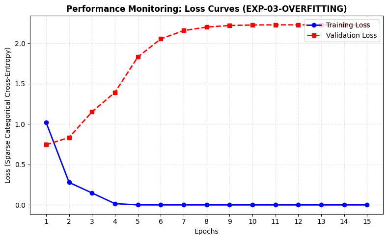

## EXP-04-REGULARIZED: Regularized High Capacity (Introduce Dropout)

**What this cell does:** Defines the hyperparameter configuration for **EXP-04-REGULARIZED** and builds the Keras model architecture from it (Pillar 1: Architecture).

**How:**

- `np.random.seed(42)` / `tf.random.set_seed(42)` are re-applied here (not just once at the top of the notebook) so this specific run's weight initialization starts from the same fixed point regardless of what earlier experiment cells already ran and consumed random state from.
- `CONFIG` bundles this run's hyperparameters: `embed_dim`=32 and `hidden_dim`=128 are Pillar 1 (Architecture); `learning_rate`=0.005, `batch_size`=32, `epochs`=15, `optimizer_type`="Adam" are Pillar 2 (Optimization); `dropout_rate`=0.4 is Pillar 3 (Regularization).
- `tf.keras.backend.clear_session()` wipes any model/graph left behind by a previous cell, so re-running cells out of order can't leak weights between experiments.
- `Sequential()` + `Input(shape=(MAX_LEN,))` declares the model and forces Keras to build it immediately, so `model.summary()` later shows real shapes instead of `?`.
- `Embedding(input_dim=len(vocab), output_dim=32, mask_zero=True)` turns each integer token into a learned 32-length vector; `mask_zero=True` tells later layers to ignore `<PAD>` positions.
- `GlobalAveragePooling1D()` averages those per-token vectors into one fixed-length vector per example — the automated feature-extraction step the lecture points to.
- `Dense(128, activation='relu')` is the hidden layer doing the actual pattern learning.
- `Dropout(0.4)` randomly zeroes hidden units during training to fight overfitting.
- `Dense(num_classes, activation='softmax')` outputs a probability over the 3 sentiment classes.

**Why:** Capacity stays high (`hidden_dim: 128`) but `dropout_rate` is raised to 0.4 — Task 2's “Regularized High Capacity” run, testing whether dropout alone can temper the overfitting a high-capacity model shows without it (as seen in EXP-03).

**What this cell does:** Builds the optimizer, compiles the model, prints its summary, trains it, and computes the validation metrics logged for **EXP-04-REGULARIZED**.

**How:**

- The `if/else` on `CONFIG["optimizer_type"]` builds either an `Adam` or `SGD` optimizer object using this run's learning rate.
- `model.compile(loss='sparse_categorical_crossentropy', optimizer=opt, metrics=['accuracy'])` — sparse categorical cross-entropy is used because the labels are plain integers (0/1/2), not one-hot vectors; `accuracy` is tracked per epoch alongside loss.
- `model.summary()` prints the layer-by-layer shape/parameter table as a sanity check before training starts.
- `history = model.fit(X_train, y_train, validation_data=(X_val, y_val), epochs=..., batch_size=..., verbose=1)` — this call *is* the training loop from the lecture: each epoch runs Forward Pass → Loss Calculation → Backward Pass → Weight Update over every mini-batch, then evaluates once on the validation set.
- `val_preds_probs = model.predict(X_val)` → `np.argmax(..., axis=1)` converts the softmax probability vector for each example into a single predicted class (0, 1, or 2).
- `f1_score(y_val, val_preds, average='weighted')` (plus `precision_score`/`recall_score`, same `average='weighted'`) weights each class's contribution by how many examples it has — matching what the exercise deliverables table asks for ("Final Validation Weighted F1-Score").
- `val_loss = history.history['val_loss'][-1]` takes the final epoch's validation loss, since this run doesn't use early stopping and always trains the full fixed epoch count.
- The final `print(...)` writes one summary line the student copies into the Excel training log.

**Why:** This cell is where EXP-04-REGULARIZED actually learns from data — the config/architecture cell above only sets the model up; this is what produces the val loss / F1 / precision / recall numbers that get compared against the PT-P1 benchmark and against every other run in the study.

```
Model: "sequential"
```

```
┏━━━━━━━━━━━━━━━━━━━━━━━━━━━━━━━━━┳━━━━━━━━━━━━━━━━━━━━━━━━┳━━━━━━━━━━━━━━━┓
┃ Layer (type)                    ┃ Output Shape           ┃       Param # ┃
┡━━━━━━━━━━━━━━━━━━━━━━━━━━━━━━━━━╇━━━━━━━━━━━━━━━━━━━━━━━━╇━━━━━━━━━━━━━━━┩
│ embedding (Embedding)           │ (None, 20, 32)         │        32,000 │
├─────────────────────────────────┼────────────────────────┼───────────────┤
│ global_average_pooling1d        │ (None, 32)             │             0 │
│ (GlobalAveragePooling1D)        │                        │               │
├─────────────────────────────────┼────────────────────────┼───────────────┤
│ dense (Dense)                   │ (None, 128)            │         4,224 │
├─────────────────────────────────┼────────────────────────┼───────────────┤
│ dropout (Dropout)               │ (None, 128)            │             0 │
├─────────────────────────────────┼────────────────────────┼───────────────┤
│ dense_1 (Dense)                 │ (None, 3)              │           387 │
└─────────────────────────────────┴────────────────────────┴───────────────┘
```

```
 Total params: 36,611 (143.01 KB)
```

```
 Trainable params: 36,611 (143.01 KB)
```

```
 Non-trainable params: 0 (0.00 B)
```

```
--- Starting Training Run: EXP-04-REGULARIZED ---
8/8 ━━━━━━━━━━━━━━━━━━━━ 2s 57ms/step - accuracy: 0.3491 - loss: 1.0971 - val_accuracy: 0.4800 - val_loss: 1.0880
8/8 ━━━━━━━━━━━━━━━━━━━━ 0s 22ms/step - accuracy: 0.6940 - loss: 1.0314 - val_accuracy: 0.6600 - val_loss: 1.0080
8/8 ━━━━━━━━━━━━━━━━━━━━ 0s 20ms/step - accuracy: 0.8966 - loss: 0.8419 - val_accuracy: 0.7600 - val_loss: 0.8269
8/8 ━━━━━━━━━━━━━━━━━━━━ 0s 17ms/step - accuracy: 0.9784 - loss: 0.4937 - val_accuracy: 0.7600 - val_loss: 0.6057
8/8 ━━━━━━━━━━━━━━━━━━━━ 0s 20ms/step - accuracy: 0.9828 - loss: 0.1890 - val_accuracy: 0.7800 - val_loss: 0.4913
8/8 ━━━━━━━━━━━━━━━━━━━━ 0s 24ms/step - accuracy: 0.9871 - loss: 0.0638 - val_accuracy: 0.7600 - val_loss: 0.4957
8/8 ━━━━━━━━━━━━━━━━━━━━ 0s 23ms/step - accuracy: 1.0000 - loss: 0.0209 - val_accuracy: 0.7800 - val_loss: 0.5433
8/8 ━━━━━━━━━━━━━━━━━━━━ 0s 21ms/step - accuracy: 1.0000 - loss: 0.0096 - val_accuracy: 0.7800 - val_loss: 0.5916
8/8 ━━━━━━━━━━━━━━━━━━━━ 0s 18ms/step - accuracy: 1.0000 - loss: 0.0044 - val_accuracy: 0.7800 - val_loss: 0.6225
8/8 ━━━━━━━━━━━━━━━━━━━━ 0s 20ms/step - accuracy: 1.0000 - loss: 0.0022 - val_accuracy: 0.7800 - val_loss: 0.6393
8/8 ━━━━━━━━━━━━━━━━━━━━ 0s 18ms/step - accuracy: 1.0000 - loss: 0.0018 - val_accuracy: 0.7800 - val_loss: 0.6525
8/8 ━━━━━━━━━━━━━━━━━━━━ 0s 11ms/step - accuracy: 1.0000 - loss: 0.0015 - val_accuracy: 0.7800 - val_loss: 0.6582
8/8 ━━━━━━━━━━━━━━━━━━━━ 0s 11ms/step - accuracy: 1.0000 - loss: 0.0016 - val_accuracy: 0.7800 - val_loss: 0.6547
8/8 ━━━━━━━━━━━━━━━━━━━━ 0s 11ms/step - accuracy: 1.0000 - loss: 0.0010 - val_accuracy: 0.7800 - val_loss: 0.6533
8/8 ━━━━━━━━━━━━━━━━━━━━ 0s 11ms/step - accuracy: 1.0000 - loss: 0.0010 - val_accuracy: 0.7800 - val_loss: 0.6551
2/2 ━━━━━━━━━━━━━━━━━━━━ 0s 75ms/step

=== EXP LOG ENTRY ===
ID: EXP-04-REGULARIZED | LR: 0.005 | Hidden: 128 | Dropout: 0.4 | Final Val Loss: 0.6551 | Final Val F1: 0.7836 | Final Val Precision: 0.8040 | Final Val Recall: 0.7800
```

**What this cell does:** Plots training loss vs. validation loss per epoch for **EXP-04-REGULARIZED** and saves the figure to Drive.

**How:**

- `train_losses`/`val_losses` are pulled straight from `history.history`, the per-epoch log Keras kept during `.fit()` in the previous cell.
- `epochs_range = range(1, CONFIG['epochs'] + 1)` — since this run doesn't use early stopping, the number of epochs plotted always matches the configured cap.
- Two lines are plotted on the same axes: training loss (blue, solid, circle markers) and validation loss (red, dashed, square markers) — putting both on one chart is what makes over/underfitting visually obvious, per the lecture's "Diagnosing Model Fit" slide (converging together = good fit, diverging = overfitting, both flat and high = underfitting).
- `plt.savefig(f'{SAVE_DIR}/{CONFIG["run_id"]}_loss_curve.png', ...)` writes a uniquely-named PNG for this run into the shared `loss_curves` Drive folder *before* `plt.show()` displays it inline, so every run's chart survives after the session ends.

**Why:** Task 3 explicitly requires saving a copy of each experiment's loss curve for the report, and this is the artifact used to classify EXP-04-REGULARIZED as underfitting, overfitting, or a good fit when writing up Discussion Question 2.

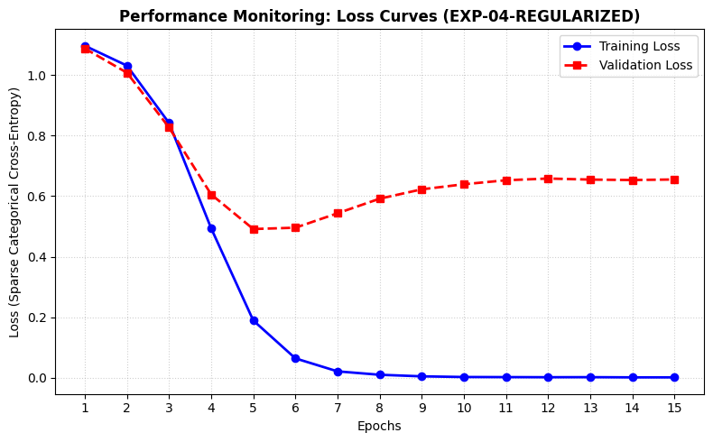

## EXP-05-OPTIMAL: Optimal Model (Fine-tune to beat PT-P1)

**What this cell does:** Defines the hyperparameter configuration for **EXP-05-OPTIMAL** and builds the Keras model architecture from it (Pillar 1: Architecture).

**How:**

- `np.random.seed(42)` / `tf.random.set_seed(42)` are re-applied here (not just once at the top of the notebook) so this specific run's weight initialization starts from the same fixed point regardless of what earlier experiment cells already ran and consumed random state from.
- `CONFIG` bundles this run's hyperparameters: `embed_dim`=64 and `hidden_dim`=128 are Pillar 1 (Architecture); `learning_rate`=0.003, `batch_size`=32, `epochs`=15, `optimizer_type`="Adam" are Pillar 2 (Optimization); `dropout_rate`=0.3 is Pillar 3 (Regularization).
- `tf.keras.backend.clear_session()` wipes any model/graph left behind by a previous cell, so re-running cells out of order can't leak weights between experiments.
- `Sequential()` + `Input(shape=(MAX_LEN,))` declares the model and forces Keras to build it immediately, so `model.summary()` later shows real shapes instead of `?`.
- `Embedding(input_dim=len(vocab), output_dim=64, mask_zero=True)` turns each integer token into a learned 64-length vector; `mask_zero=True` tells later layers to ignore `<PAD>` positions.
- `GlobalAveragePooling1D()` averages those per-token vectors into one fixed-length vector per example — the automated feature-extraction step the lecture points to.
- `Dense(128, activation='relu')` is the hidden layer doing the actual pattern learning.
- `Dropout(0.3)` randomly zeroes hidden units during training to fight overfitting.
- `Dense(num_classes, activation='softmax')` outputs a probability over the 3 sentiment classes.

**Why:** This fills Task 2's `EXP-05` “Custom” slot — a hand-picked combination (embed 64, hidden 128, LR 0.003, dropout 0.3) sitting between EXP-01's plain baseline and EXP-04's heavier regularization, as a first tuned attempt before the systematic Task 4 ablations below.

**What this cell does:** Builds the optimizer, compiles the model, prints its summary, trains it, and computes the validation metrics logged for **EXP-05-OPTIMAL**.

**How:**

- The `if/else` on `CONFIG["optimizer_type"]` builds either an `Adam` or `SGD` optimizer object using this run's learning rate.
- `model.compile(loss='sparse_categorical_crossentropy', optimizer=opt, metrics=['accuracy'])` — sparse categorical cross-entropy is used because the labels are plain integers (0/1/2), not one-hot vectors; `accuracy` is tracked per epoch alongside loss.
- `model.summary()` prints the layer-by-layer shape/parameter table as a sanity check before training starts.
- `history = model.fit(X_train, y_train, validation_data=(X_val, y_val), epochs=..., batch_size=..., verbose=1)` — this call *is* the training loop from the lecture: each epoch runs Forward Pass → Loss Calculation → Backward Pass → Weight Update over every mini-batch, then evaluates once on the validation set.
- `val_preds_probs = model.predict(X_val)` → `np.argmax(..., axis=1)` converts the softmax probability vector for each example into a single predicted class (0, 1, or 2).
- `f1_score(y_val, val_preds, average='weighted')` (plus `precision_score`/`recall_score`, same `average='weighted'`) weights each class's contribution by how many examples it has — matching what the exercise deliverables table asks for ("Final Validation Weighted F1-Score").
- `val_loss = history.history['val_loss'][-1]` takes the final epoch's validation loss, since this run doesn't use early stopping and always trains the full fixed epoch count.
- The final `print(...)` writes one summary line the student copies into the Excel training log.

**Why:** This cell is where EXP-05-OPTIMAL actually learns from data — the config/architecture cell above only sets the model up; this is what produces the val loss / F1 / precision / recall numbers that get compared against the PT-P1 benchmark and against every other run in the study.

```
Model: "sequential"
```

```
┏━━━━━━━━━━━━━━━━━━━━━━━━━━━━━━━━━┳━━━━━━━━━━━━━━━━━━━━━━━━┳━━━━━━━━━━━━━━━┓
┃ Layer (type)                    ┃ Output Shape           ┃       Param # ┃
┡━━━━━━━━━━━━━━━━━━━━━━━━━━━━━━━━━╇━━━━━━━━━━━━━━━━━━━━━━━━╇━━━━━━━━━━━━━━━┩
│ embedding (Embedding)           │ (None, 20, 64)         │        64,000 │
├─────────────────────────────────┼────────────────────────┼───────────────┤
│ global_average_pooling1d        │ (None, 64)             │             0 │
│ (GlobalAveragePooling1D)        │                        │               │
├─────────────────────────────────┼────────────────────────┼───────────────┤
│ dense (Dense)                   │ (None, 128)            │         8,320 │
├─────────────────────────────────┼────────────────────────┼───────────────┤
│ dropout (Dropout)               │ (None, 128)            │             0 │
├─────────────────────────────────┼────────────────────────┼───────────────┤
│ dense_1 (Dense)                 │ (None, 3)              │           387 │
└─────────────────────────────────┴────────────────────────┴───────────────┘
```

```
 Total params: 72,707 (284.01 KB)
```

```
 Trainable params: 72,707 (284.01 KB)
```

```
 Non-trainable params: 0 (0.00 B)
```

```
--- Starting Training Run: EXP-05-OPTIMAL ---
8/8 ━━━━━━━━━━━━━━━━━━━━ 1s 40ms/step - accuracy: 0.4483 - loss: 1.0942 - val_accuracy: 0.6000 - val_loss: 1.0798
8/8 ━━━━━━━━━━━━━━━━━━━━ 0s 12ms/step - accuracy: 0.6638 - loss: 1.0297 - val_accuracy: 0.6400 - val_loss: 1.0045
8/8 ━━━━━━━━━━━━━━━━━━━━ 0s 12ms/step - accuracy: 0.7974 - loss: 0.8810 - val_accuracy: 0.6800 - val_loss: 0.8548
8/8 ━━━━━━━━━━━━━━━━━━━━ 0s 12ms/step - accuracy: 0.8879 - loss: 0.6346 - val_accuracy: 0.7400 - val_loss: 0.6721
8/8 ━━━━━━━━━━━━━━━━━━━━ 0s 12ms/step - accuracy: 0.9655 - loss: 0.3685 - val_accuracy: 0.7800 - val_loss: 0.5301
8/8 ━━━━━━━━━━━━━━━━━━━━ 0s 11ms/step - accuracy: 0.9871 - loss: 0.1844 - val_accuracy: 0.8200 - val_loss: 0.4444
8/8 ━━━━━━━━━━━━━━━━━━━━ 0s 11ms/step - accuracy: 0.9957 - loss: 0.0766 - val_accuracy: 0.8000 - val_loss: 0.4263
8/8 ━━━━━━━━━━━━━━━━━━━━ 0s 11ms/step - accuracy: 0.9957 - loss: 0.0345 - val_accuracy: 0.8000 - val_loss: 0.4461
8/8 ━━━━━━━━━━━━━━━━━━━━ 0s 12ms/step - accuracy: 1.0000 - loss: 0.0149 - val_accuracy: 0.8000 - val_loss: 0.4742
8/8 ━━━━━━━━━━━━━━━━━━━━ 0s 11ms/step - accuracy: 1.0000 - loss: 0.0078 - val_accuracy: 0.8000 - val_loss: 0.4917
8/8 ━━━━━━━━━━━━━━━━━━━━ 0s 11ms/step - accuracy: 1.0000 - loss: 0.0049 - val_accuracy: 0.7800 - val_loss: 0.5017
8/8 ━━━━━━━━━━━━━━━━━━━━ 0s 11ms/step - accuracy: 1.0000 - loss: 0.0037 - val_accuracy: 0.8000 - val_loss: 0.5087
8/8 ━━━━━━━━━━━━━━━━━━━━ 0s 12ms/step - accuracy: 1.0000 - loss: 0.0032 - val_accuracy: 0.8000 - val_loss: 0.5157
8/8 ━━━━━━━━━━━━━━━━━━━━ 0s 12ms/step - accuracy: 1.0000 - loss: 0.0024 - val_accuracy: 0.8000 - val_loss: 0.5230
8/8 ━━━━━━━━━━━━━━━━━━━━ 0s 13ms/step - accuracy: 1.0000 - loss: 0.0024 - val_accuracy: 0.7800 - val_loss: 0.5301
2/2 ━━━━━━━━━━━━━━━━━━━━ 0s 73ms/step

=== EXP LOG ENTRY ===
ID: EXP-05-OPTIMAL | LR: 0.003 | Hidden: 128 | Dropout: 0.3 | Final Val Loss: 0.5301 | Final Val F1: 0.7841 | Final Val Precision: 0.7939 | Final Val Recall: 0.7800
```

**What this cell does:** Plots training loss vs. validation loss per epoch for **EXP-05-OPTIMAL** and saves the figure to Drive.

**How:**

- `train_losses`/`val_losses` are pulled straight from `history.history`, the per-epoch log Keras kept during `.fit()` in the previous cell.
- `epochs_range = range(1, CONFIG['epochs'] + 1)` — since this run doesn't use early stopping, the number of epochs plotted always matches the configured cap.
- Two lines are plotted on the same axes: training loss (blue, solid, circle markers) and validation loss (red, dashed, square markers) — putting both on one chart is what makes over/underfitting visually obvious, per the lecture's "Diagnosing Model Fit" slide (converging together = good fit, diverging = overfitting, both flat and high = underfitting).
- `plt.savefig(f'{SAVE_DIR}/{CONFIG["run_id"]}_loss_curve.png', ...)` writes a uniquely-named PNG for this run into the shared `loss_curves` Drive folder *before* `plt.show()` displays it inline, so every run's chart survives after the session ends.

**Why:** Task 3 explicitly requires saving a copy of each experiment's loss curve for the report, and this is the artifact used to classify EXP-05-OPTIMAL as underfitting, overfitting, or a good fit when writing up Discussion Question 2.

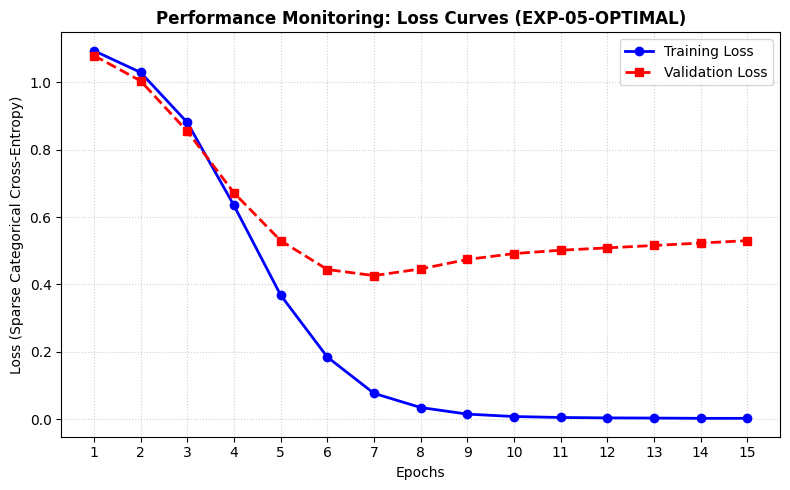

# Task 4: Free-Form Optimization & Maximum Performance Extraction

Each run below changes exactly **one** lever from the EXP-01 baseline configuration, so its effect can be judged in isolation before combining whichever changes actually helped into a final champion run. This keeps each result attributable to a specific cause rather than a bundle of simultaneous changes.

## EXP-05A-EARLY-STOPPING: Baseline + Early Stopping

Isolates the effect of stopping training near the validation-loss minimum (observed around epoch 6-7 across EXP-01, EXP-04, and EXP-05) instead of training the full 15 epochs. All other hyperparameters match the EXP-01 baseline exactly, so any change in the result can be attributed to early stopping alone.

**What this cell does:** Defines the hyperparameter configuration for **EXP-05A-EARLY-STOPPING** and builds the Keras model architecture from it (Pillar 1: Architecture).

**How:**

- `np.random.seed(42)` / `tf.random.set_seed(42)` are re-applied here (not just once at the top of the notebook) so this specific run's weight initialization starts from the same fixed point regardless of what earlier experiment cells already ran and consumed random state from.
- `CONFIG` bundles this run's hyperparameters: `embed_dim`=32 and `hidden_dim`=64 are Pillar 1 (Architecture); `learning_rate`=0.005, `batch_size`=32, `epochs`=20, `optimizer_type`="Adam" are Pillar 2 (Optimization); `dropout_rate`=0.1 is Pillar 3 (Regularization).
- `patience`: 3 is also set here, used by the `EarlyStopping` callback in the next cell.
- `tf.keras.backend.clear_session()` wipes any model/graph left behind by a previous cell, so re-running cells out of order can't leak weights between experiments.
- `Sequential()` + `Input(shape=(MAX_LEN,))` declares the model and forces Keras to build it immediately, so `model.summary()` later shows real shapes instead of `?`.
- `Embedding(input_dim=len(vocab), output_dim=32, mask_zero=True)` turns each integer token into a learned 32-length vector; `mask_zero=True` tells later layers to ignore `<PAD>` positions.
- `GlobalAveragePooling1D()` averages those per-token vectors into one fixed-length vector per example — the automated feature-extraction step the lecture points to.
- `Dense(64, activation='relu')` is the hidden layer doing the actual pattern learning.
- `Dropout(0.1)` randomly zeroes hidden units during training to fight overfitting.
- `Dense(num_classes, activation='softmax')` outputs a probability over the 3 sentiment classes.

**Why:** Every hyperparameter matches the EXP-01 baseline exactly (embed 32, hidden 64, LR 0.005, dropout 0.1). The only changes are `epochs` raised to 20 (so EarlyStopping has room to trigger) and a `patience` key added. Holding everything else fixed means any F1/loss improvement over EXP-01 can be attributed specifically to early stopping, not to some other change.

**What this cell does:** Builds the optimizer, compiles the model, prints its summary, trains it, and computes the validation metrics logged for **EXP-05A-EARLY-STOPPING**.

**How:**

- The `if/else` on `CONFIG["optimizer_type"]` builds either an `Adam` or `SGD` optimizer object using this run's learning rate.
- `model.compile(loss='sparse_categorical_crossentropy', optimizer=opt, metrics=['accuracy'])` — sparse categorical cross-entropy is used because the labels are plain integers (0/1/2), not one-hot vectors; `accuracy` is tracked per epoch alongside loss.
- `model.summary()` prints the layer-by-layer shape/parameter table as a sanity check before training starts.
- `EarlyStopping(monitor='val_loss', patience=CONFIG['patience'], restore_best_weights=True)` watches validation loss; if it doesn't improve for `patience` consecutive epochs, training stops and Keras rolls the model's weights back to whichever epoch had the lowest `val_loss` (not the last epoch run).
- `history = model.fit(X_train, y_train, validation_data=(X_val, y_val), epochs=..., batch_size=..., callbacks=[early_stop], verbose=1)` — this call *is* the training loop from the lecture: each epoch runs Forward Pass → Loss Calculation → Backward Pass → Weight Update over every mini-batch, then evaluates once on the validation set.
- `val_preds_probs = model.predict(X_val)` → `np.argmax(..., axis=1)` converts the softmax probability vector for each example into a single predicted class (0, 1, or 2).
- `f1_score(y_val, val_preds, average='weighted')` (plus `precision_score`/`recall_score`, same `average='weighted'`) weights each class's contribution by how many examples it has — matching what the exercise deliverables table asks for ("Final Validation Weighted F1-Score").
- `val_loss = min(history.history['val_loss'])`, **not** `[-1]` — because `restore_best_weights=True` means the model's actual weights come from the best epoch, so reporting the last epoch's logged loss would describe a model that's no longer in memory.
- The final `print(...)` writes one summary line the student copies into the Excel training log.

**Why:** This cell is where EXP-05A-EARLY-STOPPING actually learns from data — the config/architecture cell above only sets the model up; this is what produces the val loss / F1 / precision / recall numbers that get compared against the PT-P1 benchmark and against every other run in the study.

```
Model: "sequential"
```

```
┏━━━━━━━━━━━━━━━━━━━━━━━━━━━━━━━━━┳━━━━━━━━━━━━━━━━━━━━━━━━┳━━━━━━━━━━━━━━━┓
┃ Layer (type)                    ┃ Output Shape           ┃       Param # ┃
┡━━━━━━━━━━━━━━━━━━━━━━━━━━━━━━━━━╇━━━━━━━━━━━━━━━━━━━━━━━━╇━━━━━━━━━━━━━━━┩
│ embedding (Embedding)           │ (None, 20, 32)         │        32,000 │
├─────────────────────────────────┼────────────────────────┼───────────────┤
│ global_average_pooling1d        │ (None, 32)             │             0 │
│ (GlobalAveragePooling1D)        │                        │               │
├─────────────────────────────────┼────────────────────────┼───────────────┤
│ dense (Dense)                   │ (None, 64)             │         2,112 │
├─────────────────────────────────┼────────────────────────┼───────────────┤
│ dropout (Dropout)               │ (None, 64)             │             0 │
├─────────────────────────────────┼────────────────────────┼───────────────┤
│ dense_1 (Dense)                 │ (None, 3)              │           195 │
└─────────────────────────────────┴────────────────────────┴───────────────┘
```

```
 Total params: 34,307 (134.01 KB)
```

```
 Trainable params: 34,307 (134.01 KB)
```

```
 Non-trainable params: 0 (0.00 B)
```

```
--- Starting Training Run: EXP-05A-EARLY-STOPPING ---
8/8 ━━━━━━━━━━━━━━━━━━━━ 1s 39ms/step - accuracy: 0.4483 - loss: 1.0917 - val_accuracy: 0.6200 - val_loss: 1.0719
8/8 ━━━━━━━━━━━━━━━━━━━━ 0s 12ms/step - accuracy: 0.6983 - loss: 0.9996 - val_accuracy: 0.7000 - val_loss: 0.9757
8/8 ━━━━━━━━━━━━━━━━━━━━ 0s 12ms/step - accuracy: 0.8922 - loss: 0.8067 - val_accuracy: 0.7200 - val_loss: 0.8122
8/8 ━━━━━━━━━━━━━━━━━━━━ 0s 12ms/step - accuracy: 0.9310 - loss: 0.5424 - val_accuracy: 0.7400 - val_loss: 0.6434
8/8 ━━━━━━━━━━━━━━━━━━━━ 0s 11ms/step - accuracy: 0.9655 - loss: 0.2955 - val_accuracy: 0.7800 - val_loss: 0.5210
8/8 ━━━━━━━━━━━━━━━━━━━━ 0s 14ms/step - accuracy: 0.9871 - loss: 0.1315 - val_accuracy: 0.8000 - val_loss: 0.4669
8/8 ━━━━━━━━━━━━━━━━━━━━ 0s 11ms/step - accuracy: 0.9957 - loss: 0.0499 - val_accuracy: 0.7800 - val_loss: 0.4727
8/8 ━━━━━━━━━━━━━━━━━━━━ 0s 11ms/step - accuracy: 1.0000 - loss: 0.0204 - val_accuracy: 0.7800 - val_loss: 0.5002
8/8 ━━━━━━━━━━━━━━━━━━━━ 0s 11ms/step - accuracy: 1.0000 - loss: 0.0105 - val_accuracy: 0.7800 - val_loss: 0.5288
Epoch 9: early stopping
Restoring model weights from the end of the best epoch: 6.
2/2 ━━━━━━━━━━━━━━━━━━━━ 0s 72ms/step

=== EXP LOG ENTRY ===
ID: EXP-05A-EARLY-STOPPING | LR: 0.005 | Hidden: 64 | Dropout: 0.1 | Epochs Trained: 9/20 | Final Val Loss: 0.4669 | Final Val F1: 0.7967 | Final Val Precision: 0.8052 | Final Val Recall: 0.8000
```

**What this cell does:** Plots training loss vs. validation loss per epoch for **EXP-05A-EARLY-STOPPING** and saves the figure to Drive.

**How:**

- `train_losses`/`val_losses` are pulled straight from `history.history`, the per-epoch log Keras kept during `.fit()` in the previous cell.
- `epochs_range = range(1, len(train_losses) + 1)` — uses the *actual* number of epochs completed (`len(train_losses)`), not `CONFIG['epochs']`, because EarlyStopping may have halted training before reaching the configured cap.
- Two lines are plotted on the same axes: training loss (blue, solid, circle markers) and validation loss (red, dashed, square markers) — putting both on one chart is what makes over/underfitting visually obvious, per the lecture's "Diagnosing Model Fit" slide (converging together = good fit, diverging = overfitting, both flat and high = underfitting).
- `plt.savefig(f'{SAVE_DIR}/{CONFIG["run_id"]}_loss_curve.png', ...)` writes a uniquely-named PNG for this run into the shared `loss_curves` Drive folder *before* `plt.show()` displays it inline, so every run's chart survives after the session ends.

**Why:** Task 3 explicitly requires saving a copy of each experiment's loss curve for the report, and this is the artifact used to classify EXP-05A-EARLY-STOPPING as underfitting, overfitting, or a good fit when writing up Discussion Question 2.

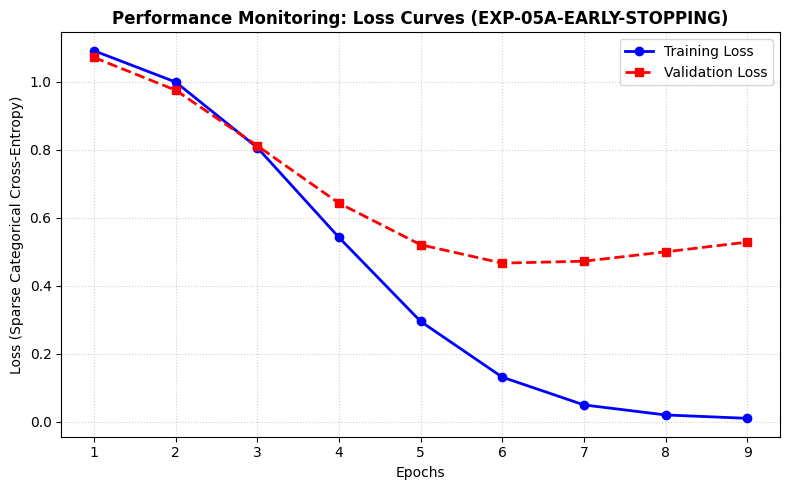

## EXP-05B-EXPANDED-DATA: Baseline + Dataset Expansion

Isolates the effect of adding more training data — combining the PT-P1 dataset with `sample_dataset.csv` (or additional written examples), keeping class balance — while holding every hyperparameter at the EXP-01 baseline values. Any change in the result can be attributed to the expanded dataset alone.

**Fill in `EXPANSION_CSV_FILEPATH` below before running.**

**What this cell does:** Builds the expanded training set for `EXP-05B` onward by combining the original PT-P1 dataset with the extra hand-written examples in `pt_p1_dataset_expansion.csv`, then rebuilds the vocabulary/encodings/splits on the combined data.

**How:**

- `EXPANSION_CSV_FILEPATH` points at the second CSV of new examples.
- `pd.concat([df_original, df_expansion])` stacks the two DataFrames into one 452-row dataset.
- The two `print(...value_counts())` calls show the class balance before and after merging, so it's visible at a glance that the merge kept the classes roughly balanced (151/151/150) rather than skewing the model toward one label.
- `build_vocab` / `text_to_sequence` / `train_test_split` are called again — identical logic to the very first data cell, just applied to `df_combined` — and the results **overwrite the global `vocab`, `X_data`, `y_data`, `X_train`, `X_val`, `X_test`, `num_classes`** that every cell below currently relies on, until they're reloaded again later.

**Why:** Task 4 explicitly lists "adding more training data instances" as one of the allowed free-form optimization levers, and PT-P1's own report found volume alone didn't fix its sarcasm/ ambiguity blind spot — it needed *representative* data covering the failure pattern. Keeping class balance while expanding avoids introducing a new bias in the process. The comment in the code flags on purpose that `EXP-05C` through `EXP-05H` all build on top of this expanded state, while `EXP-05I`/`EXP-05J` later reload data independently — that's intentional, so those two ablations aren't accidentally contaminated by whatever this cell left in memory.

```
--- Class balance BEFORE expansion ---
label
1    111
0    111
2    110
Name: count, dtype: int64

--- Class balance AFTER expansion ---
label
1    151
0    151
2    150
Name: count, dtype: int64

Total examples: 332 -> 452

New split sizes -- Train: 316, Val: 68, Test: 68
Vocabulary size: 1000
```

**What this cell does:** Defines the hyperparameter configuration for **EXP-05B-EXPANDED-DATA** and builds the Keras model architecture from it (Pillar 1: Architecture).

**How:**

- `np.random.seed(42)` / `tf.random.set_seed(42)` are re-applied here (not just once at the top of the notebook) so this specific run's weight initialization starts from the same fixed point regardless of what earlier experiment cells already ran and consumed random state from.
- `CONFIG` bundles this run's hyperparameters: `embed_dim`=32 and `hidden_dim`=64 are Pillar 1 (Architecture); `learning_rate`=0.005, `batch_size`=32, `epochs`=15, `optimizer_type`="Adam" are Pillar 2 (Optimization); `dropout_rate`=0.1 is Pillar 3 (Regularization).
- `tf.keras.backend.clear_session()` wipes any model/graph left behind by a previous cell, so re-running cells out of order can't leak weights between experiments.
- `Sequential()` + `Input(shape=(MAX_LEN,))` declares the model and forces Keras to build it immediately, so `model.summary()` later shows real shapes instead of `?`.
- `Embedding(input_dim=len(vocab), output_dim=32, mask_zero=True)` turns each integer token into a learned 32-length vector; `mask_zero=True` tells later layers to ignore `<PAD>` positions.
- `GlobalAveragePooling1D()` averages those per-token vectors into one fixed-length vector per example — the automated feature-extraction step the lecture points to.
- `Dense(64, activation='relu')` is the hidden layer doing the actual pattern learning.
- `Dropout(0.1)` randomly zeroes hidden units during training to fight overfitting.
- `Dense(num_classes, activation='softmax')` outputs a probability over the 3 sentiment classes.

**Why:** Hyperparameters again match EXP-01 exactly. The only difference is *what data* this model trains on (built in the cell above by combining the original and expansion CSVs). Holding hyperparameters fixed isolates the effect of more/more-diverse data on its own.

**What this cell does:** Builds the optimizer, compiles the model, prints its summary, trains it, and computes the validation metrics logged for **EXP-05B-EXPANDED-DATA**.

**How:**

- The `if/else` on `CONFIG["optimizer_type"]` builds either an `Adam` or `SGD` optimizer object using this run's learning rate.
- `model.compile(loss='sparse_categorical_crossentropy', optimizer=opt, metrics=['accuracy'])` — sparse categorical cross-entropy is used because the labels are plain integers (0/1/2), not one-hot vectors; `accuracy` is tracked per epoch alongside loss.
- `model.summary()` prints the layer-by-layer shape/parameter table as a sanity check before training starts.
- `history = model.fit(X_train, y_train, validation_data=(X_val, y_val), epochs=..., batch_size=..., verbose=1)` — this call *is* the training loop from the lecture: each epoch runs Forward Pass → Loss Calculation → Backward Pass → Weight Update over every mini-batch, then evaluates once on the validation set.
- `val_preds_probs = model.predict(X_val)` → `np.argmax(..., axis=1)` converts the softmax probability vector for each example into a single predicted class (0, 1, or 2).
- `f1_score(y_val, val_preds, average='weighted')` (plus `precision_score`/`recall_score`, same `average='weighted'`) weights each class's contribution by how many examples it has — matching what the exercise deliverables table asks for ("Final Validation Weighted F1-Score").
- `val_loss = history.history['val_loss'][-1]` takes the final epoch's validation loss, since this run doesn't use early stopping and always trains the full fixed epoch count.
- The final `print(...)` writes one summary line the student copies into the Excel training log.

**Why:** This cell is where EXP-05B-EXPANDED-DATA actually learns from data — the config/architecture cell above only sets the model up; this is what produces the val loss / F1 / precision / recall numbers that get compared against the PT-P1 benchmark and against every other run in the study.

```
Model: "sequential"
```

```
┏━━━━━━━━━━━━━━━━━━━━━━━━━━━━━━━━━┳━━━━━━━━━━━━━━━━━━━━━━━━┳━━━━━━━━━━━━━━━┓
┃ Layer (type)                    ┃ Output Shape           ┃       Param # ┃
┡━━━━━━━━━━━━━━━━━━━━━━━━━━━━━━━━━╇━━━━━━━━━━━━━━━━━━━━━━━━╇━━━━━━━━━━━━━━━┩
│ embedding (Embedding)           │ (None, 20, 32)         │        32,000 │
├─────────────────────────────────┼────────────────────────┼───────────────┤
│ global_average_pooling1d        │ (None, 32)             │             0 │
│ (GlobalAveragePooling1D)        │                        │               │
├─────────────────────────────────┼────────────────────────┼───────────────┤
│ dense (Dense)                   │ (None, 64)             │         2,112 │
├─────────────────────────────────┼────────────────────────┼───────────────┤
│ dropout (Dropout)               │ (None, 64)             │             0 │
├─────────────────────────────────┼────────────────────────┼───────────────┤
│ dense_1 (Dense)                 │ (None, 3)              │           195 │
└─────────────────────────────────┴────────────────────────┴───────────────┘
```

```
 Total params: 34,307 (134.01 KB)
```

```
 Trainable params: 34,307 (134.01 KB)
```

```
 Non-trainable params: 0 (0.00 B)
```

```
--- Starting Training Run: EXP-05B-EXPANDED-DATA ---
10/10 ━━━━━━━━━━━━━━━━━━━━ 2s 45ms/step - accuracy: 0.3734 - loss: 1.0864 - val_accuracy: 0.4265 - val_loss: 1.0585
10/10 ━━━━━━━━━━━━━━━━━━━━ 0s 16ms/step - accuracy: 0.7532 - loss: 0.9645 - val_accuracy: 0.5735 - val_loss: 0.9127
10/10 ━━━━━━━━━━━━━━━━━━━━ 0s 13ms/step - accuracy: 0.8386 - loss: 0.7003 - val_accuracy: 0.6324 - val_loss: 0.7041
10/10 ━━━━━━━━━━━━━━━━━━━━ 0s 15ms/step - accuracy: 0.9177 - loss: 0.4476 - val_accuracy: 0.7794 - val_loss: 0.5662
10/10 ━━━━━━━━━━━━━━━━━━━━ 0s 16ms/step - accuracy: 0.9778 - loss: 0.2554 - val_accuracy: 0.8088 - val_loss: 0.4776
10/10 ━━━━━━━━━━━━━━━━━━━━ 0s 15ms/step - accuracy: 0.9778 - loss: 0.1267 - val_accuracy: 0.8235 - val_loss: 0.4461
10/10 ━━━━━━━━━━━━━━━━━━━━ 0s 17ms/step - accuracy: 0.9937 - loss: 0.0503 - val_accuracy: 0.8235 - val_loss: 0.4342
10/10 ━━━━━━━━━━━━━━━━━━━━ 0s 18ms/step - accuracy: 1.0000 - loss: 0.0192 - val_accuracy: 0.8088 - val_loss: 0.4676
10/10 ━━━━━━━━━━━━━━━━━━━━ 0s 18ms/step - accuracy: 1.0000 - loss: 0.0091 - val_accuracy: 0.8088 - val_loss: 0.5021
10/10 ━━━━━━━━━━━━━━━━━━━━ 0s 9ms/step - accuracy: 1.0000 - loss: 0.0061 - val_accuracy: 0.8088 - val_loss: 0.5385
10/10 ━━━━━━━━━━━━━━━━━━━━ 0s 9ms/step - accuracy: 1.0000 - loss: 0.0033 - val_accuracy: 0.8088 - val_loss: 0.5690
10/10 ━━━━━━━━━━━━━━━━━━━━ 0s 14ms/step - accuracy: 1.0000 - loss: 0.0027 - val_accuracy: 0.8088 - val_loss: 0.5874
10/10 ━━━━━━━━━━━━━━━━━━━━ 0s 9ms/step - accuracy: 1.0000 - loss: 0.0021 - val_accuracy: 0.8088 - val_loss: 0.6003
10/10 ━━━━━━━━━━━━━━━━━━━━ 0s 10ms/step - accuracy: 1.0000 - loss: 0.0018 - val_accuracy: 0.8088 - val_loss: 0.6141
10/10 ━━━━━━━━━━━━━━━━━━━━ 0s 9ms/step - accuracy: 1.0000 - loss: 0.0017 - val_accuracy: 0.8088 - val_loss: 0.6301
3/3 ━━━━━━━━━━━━━━━━━━━━ 0s 36ms/step

=== EXP LOG ENTRY ===
ID: EXP-05B-EXPANDED-DATA | LR: 0.005 | Hidden: 64 | Dropout: 0.1 | Final Val Loss: 0.6301 | Final Val F1: 0.8095 | Final Val Precision: 0.8136 | Final Val Recall: 0.8088
```

**What this cell does:** Plots training loss vs. validation loss per epoch for **EXP-05B-EXPANDED-DATA** and saves the figure to Drive.

**How:**

- `train_losses`/`val_losses` are pulled straight from `history.history`, the per-epoch log Keras kept during `.fit()` in the previous cell.
- `epochs_range = range(1, CONFIG['epochs'] + 1)` — since this run doesn't use early stopping, the number of epochs plotted always matches the configured cap.
- Two lines are plotted on the same axes: training loss (blue, solid, circle markers) and validation loss (red, dashed, square markers) — putting both on one chart is what makes over/underfitting visually obvious, per the lecture's "Diagnosing Model Fit" slide (converging together = good fit, diverging = overfitting, both flat and high = underfitting).
- `plt.savefig(f'{SAVE_DIR}/{CONFIG["run_id"]}_loss_curve.png', ...)` writes a uniquely-named PNG for this run into the shared `loss_curves` Drive folder *before* `plt.show()` displays it inline, so every run's chart survives after the session ends.

**Why:** Task 3 explicitly requires saving a copy of each experiment's loss curve for the report, and this is the artifact used to classify EXP-05B-EXPANDED-DATA as underfitting, overfitting, or a good fit when writing up Discussion Question 2.

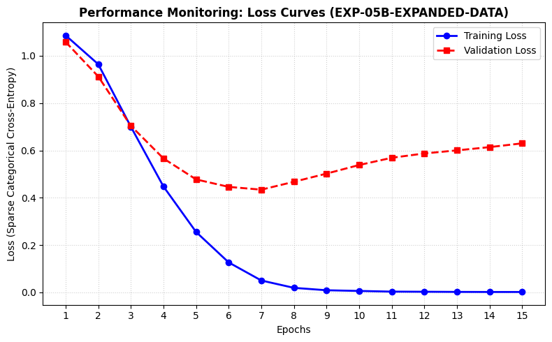

## EXP-05C-COMBINED: Expanded Data + Early Stopping

Combines the two changes that each helped independently: EXP-05B's expanded dataset (better F1, still overfit) and EXP-05A's early stopping (contained overfitting, slightly lower F1). Tests whether stacking them produces a genuine champion result rather than either partial improvement alone.

**Run this only after the EXP-05B data-expansion cell above has already executed in this session** -- this cell trains on the same expanded `X_train` / `X_val` that EXP-05B built, it does not reload or re-expand the data itself.

**What this cell does:** Defines the hyperparameter configuration for **EXP-05C-COMBINED** and builds the Keras model architecture from it (Pillar 1: Architecture).

**How:**

- `np.random.seed(42)` / `tf.random.set_seed(42)` are re-applied here (not just once at the top of the notebook) so this specific run's weight initialization starts from the same fixed point regardless of what earlier experiment cells already ran and consumed random state from.
- `CONFIG` bundles this run's hyperparameters: `embed_dim`=32 and `hidden_dim`=64 are Pillar 1 (Architecture); `learning_rate`=0.005, `batch_size`=32, `epochs`=20, `optimizer_type`="Adam" are Pillar 2 (Optimization); `dropout_rate`=0.1 is Pillar 3 (Regularization).
- `patience`: 3 is also set here, used by the `EarlyStopping` callback in the next cell.
- `tf.keras.backend.clear_session()` wipes any model/graph left behind by a previous cell, so re-running cells out of order can't leak weights between experiments.
- `Sequential()` + `Input(shape=(MAX_LEN,))` declares the model and forces Keras to build it immediately, so `model.summary()` later shows real shapes instead of `?`.
- `Embedding(input_dim=len(vocab), output_dim=32, mask_zero=True)` turns each integer token into a learned 32-length vector; `mask_zero=True` tells later layers to ignore `<PAD>` positions.
- `GlobalAveragePooling1D()` averages those per-token vectors into one fixed-length vector per example — the automated feature-extraction step the lecture points to.
- `Dense(64, activation='relu')` is the hidden layer doing the actual pattern learning.
- `Dropout(0.1)` randomly zeroes hidden units during training to fight overfitting.
- `Dense(num_classes, activation='softmax')` outputs a probability over the 3 sentiment classes.

**Why:** Stacks the two changes that each helped independently — EXP-05A's early stopping and EXP-05B's expanded data — into one config (epochs raised to 20, `patience` added, trained on the expanded dataset). This becomes the shared baseline that EXP-05D through EXP-05J below each mutate by exactly one more variable.

**What this cell does:** Builds the optimizer, compiles the model, prints its summary, trains it, and computes the validation metrics logged for **EXP-05C-COMBINED**.

**How:**

- The `if/else` on `CONFIG["optimizer_type"]` builds either an `Adam` or `SGD` optimizer object using this run's learning rate.
- `model.compile(loss='sparse_categorical_crossentropy', optimizer=opt, metrics=['accuracy'])` — sparse categorical cross-entropy is used because the labels are plain integers (0/1/2), not one-hot vectors; `accuracy` is tracked per epoch alongside loss.
- `model.summary()` prints the layer-by-layer shape/parameter table as a sanity check before training starts.
- `EarlyStopping(monitor='val_loss', patience=CONFIG['patience'], restore_best_weights=True)` watches validation loss; if it doesn't improve for `patience` consecutive epochs, training stops and Keras rolls the model's weights back to whichever epoch had the lowest `val_loss` (not the last epoch run).
- `history = model.fit(X_train, y_train, validation_data=(X_val, y_val), epochs=..., batch_size=..., callbacks=[early_stop], verbose=1)` — this call *is* the training loop from the lecture: each epoch runs Forward Pass → Loss Calculation → Backward Pass → Weight Update over every mini-batch, then evaluates once on the validation set.
- `val_preds_probs = model.predict(X_val)` → `np.argmax(..., axis=1)` converts the softmax probability vector for each example into a single predicted class (0, 1, or 2).
- `f1_score(y_val, val_preds, average='weighted')` (plus `precision_score`/`recall_score`, same `average='weighted'`) weights each class's contribution by how many examples it has — matching what the exercise deliverables table asks for ("Final Validation Weighted F1-Score").
- `val_loss = min(history.history['val_loss'])`, **not** `[-1]` — because `restore_best_weights=True` means the model's actual weights come from the best epoch, so reporting the last epoch's logged loss would describe a model that's no longer in memory.
- The final `print(...)` writes one summary line the student copies into the Excel training log.

**Why:** This cell is where EXP-05C-COMBINED actually learns from data — the config/architecture cell above only sets the model up; this is what produces the val loss / F1 / precision / recall numbers that get compared against the PT-P1 benchmark and against every other run in the study.

```
Model: "sequential"
```

```
┏━━━━━━━━━━━━━━━━━━━━━━━━━━━━━━━━━┳━━━━━━━━━━━━━━━━━━━━━━━━┳━━━━━━━━━━━━━━━┓
┃ Layer (type)                    ┃ Output Shape           ┃       Param # ┃
┡━━━━━━━━━━━━━━━━━━━━━━━━━━━━━━━━━╇━━━━━━━━━━━━━━━━━━━━━━━━╇━━━━━━━━━━━━━━━┩
│ embedding (Embedding)           │ (None, 20, 32)         │        32,000 │
├─────────────────────────────────┼────────────────────────┼───────────────┤
│ global_average_pooling1d        │ (None, 32)             │             0 │
│ (GlobalAveragePooling1D)        │                        │               │
├─────────────────────────────────┼────────────────────────┼───────────────┤
│ dense (Dense)                   │ (None, 64)             │         2,112 │
├─────────────────────────────────┼────────────────────────┼───────────────┤
│ dropout (Dropout)               │ (None, 64)             │             0 │
├─────────────────────────────────┼────────────────────────┼───────────────┤
│ dense_1 (Dense)                 │ (None, 3)              │           195 │
└─────────────────────────────────┴────────────────────────┴───────────────┘
```

```
 Total params: 34,307 (134.01 KB)
```

```
 Trainable params: 34,307 (134.01 KB)
```

```
 Non-trainable params: 0 (0.00 B)
```

```
--- Starting Training Run: EXP-05C-COMBINED ---
10/10 ━━━━━━━━━━━━━━━━━━━━ 1s 32ms/step - accuracy: 0.3639 - loss: 1.0926 - val_accuracy: 0.4853 - val_loss: 1.0779
10/10 ━━━━━━━━━━━━━━━━━━━━ 0s 10ms/step - accuracy: 0.8006 - loss: 0.9989 - val_accuracy: 0.7353 - val_loss: 0.9588
10/10 ━━━━━━━━━━━━━━━━━━━━ 0s 10ms/step - accuracy: 0.8924 - loss: 0.7353 - val_accuracy: 0.8382 - val_loss: 0.7282
10/10 ━━━━━━━━━━━━━━━━━━━━ 0s 10ms/step - accuracy: 0.9525 - loss: 0.3884 - val_accuracy: 0.8382 - val_loss: 0.5336
10/10 ━━━━━━━━━━━━━━━━━━━━ 0s 19ms/step - accuracy: 0.9810 - loss: 0.1511 - val_accuracy: 0.8382 - val_loss: 0.4517
10/10 ━━━━━━━━━━━━━━━━━━━━ 0s 30ms/step - accuracy: 1.0000 - loss: 0.0534 - val_accuracy: 0.8235 - val_loss: 0.4629
10/10 ━━━━━━━━━━━━━━━━━━━━ 0s 10ms/step - accuracy: 1.0000 - loss: 0.0201 - val_accuracy: 0.8235 - val_loss: 0.5046
10/10 ━━━━━━━━━━━━━━━━━━━━ 0s 10ms/step - accuracy: 1.0000 - loss: 0.0098 - val_accuracy: 0.8235 - val_loss: 0.5397
Epoch 8: early stopping
Restoring model weights from the end of the best epoch: 5.
3/3 ━━━━━━━━━━━━━━━━━━━━ 0s 38ms/step

=== EXP LOG ENTRY ===
ID: EXP-05C-COMBINED | LR: 0.005 | Hidden: 64 | Dropout: 0.1 | Epochs Trained: 8/20 | Final Val Loss: 0.4517 | Final Val F1: 0.8377 | Final Val Precision: 0.8377 | Final Val Recall: 0.8382
```

**What this cell does:** Plots training loss vs. validation loss per epoch for **EXP-05C-COMBINED** and saves the figure to Drive.

**How:**

- `train_losses`/`val_losses` are pulled straight from `history.history`, the per-epoch log Keras kept during `.fit()` in the previous cell.
- `epochs_range = range(1, len(train_losses) + 1)` — uses the *actual* number of epochs completed (`len(train_losses)`), not `CONFIG['epochs']`, because EarlyStopping may have halted training before reaching the configured cap.
- Two lines are plotted on the same axes: training loss (blue, solid, circle markers) and validation loss (red, dashed, square markers) — putting both on one chart is what makes over/underfitting visually obvious, per the lecture's "Diagnosing Model Fit" slide (converging together = good fit, diverging = overfitting, both flat and high = underfitting).
- `plt.savefig(f'{SAVE_DIR}/{CONFIG["run_id"]}_loss_curve.png', ...)` writes a uniquely-named PNG for this run into the shared `loss_curves` Drive folder *before* `plt.show()` displays it inline, so every run's chart survives after the session ends.

**Why:** Task 3 explicitly requires saving a copy of each experiment's loss curve for the report, and this is the artifact used to classify EXP-05C-COMBINED as underfitting, overfitting, or a good fit when writing up Discussion Question 2.

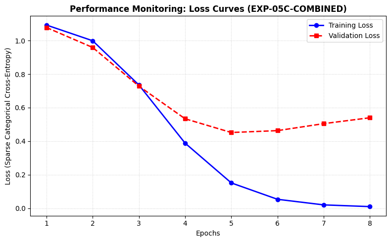

## EXP-05D-HIGHER-CAPACITY: EXP-05C + Increased Hidden Dimension

Starts from EXP-05C's setup (expanded data + early stopping) and changes exactly one more thing: `hidden_dim` 64 -> 128. Tests whether the ~14.6-point train/val accuracy gap remaining in EXP-05C is partly a capacity bottleneck -- i.e. whether the larger, more diverse dataset from EXP-05B can now support a bigger model without immediately overfitting past what early stopping can contain.

**Run this only after the EXP-05B data-expansion cell has already executed in this session** -- like EXP-05C, this trains on the same expanded `X_train` / `X_val`, it does not reload or re-expand the data itself.

**What this cell does:** Defines the hyperparameter configuration for **EXP-05D-HIGHER-CAPACITY** and builds the Keras model architecture from it (Pillar 1: Architecture).

**How:**

- `np.random.seed(42)` / `tf.random.set_seed(42)` are re-applied here (not just once at the top of the notebook) so this specific run's weight initialization starts from the same fixed point regardless of what earlier experiment cells already ran and consumed random state from.
- `CONFIG` bundles this run's hyperparameters: `embed_dim`=32 and `hidden_dim`=128 are Pillar 1 (Architecture); `learning_rate`=0.005, `batch_size`=32, `epochs`=20, `optimizer_type`="Adam" are Pillar 2 (Optimization); `dropout_rate`=0.1 is Pillar 3 (Regularization).
- `patience`: 3 is also set here, used by the `EarlyStopping` callback in the next cell.
- `tf.keras.backend.clear_session()` wipes any model/graph left behind by a previous cell, so re-running cells out of order can't leak weights between experiments.
- `Sequential()` + `Input(shape=(MAX_LEN,))` declares the model and forces Keras to build it immediately, so `model.summary()` later shows real shapes instead of `?`.
- `Embedding(input_dim=len(vocab), output_dim=32, mask_zero=True)` turns each integer token into a learned 32-length vector; `mask_zero=True` tells later layers to ignore `<PAD>` positions.
- `GlobalAveragePooling1D()` averages those per-token vectors into one fixed-length vector per example — the automated feature-extraction step the lecture points to.
- `Dense(128, activation='relu')` is the hidden layer doing the actual pattern learning.
- `Dropout(0.1)` randomly zeroes hidden units during training to fight overfitting.
- `Dense(num_classes, activation='softmax')` outputs a probability over the 3 sentiment classes.

**Why:** Identical to EXP-05C except `hidden_dim`: 64→128 — the only lever changed. Tests whether the larger, more diverse dataset from EXP-05B can now support a bigger model without overfitting faster than early stopping can contain.

**What this cell does:** Builds the optimizer, compiles the model, prints its summary, trains it, and computes the validation metrics logged for **EXP-05D-HIGHER-CAPACITY**.

**How:**

- The `if/else` on `CONFIG["optimizer_type"]` builds either an `Adam` or `SGD` optimizer object using this run's learning rate.
- `model.compile(loss='sparse_categorical_crossentropy', optimizer=opt, metrics=['accuracy'])` — sparse categorical cross-entropy is used because the labels are plain integers (0/1/2), not one-hot vectors; `accuracy` is tracked per epoch alongside loss.
- `model.summary()` prints the layer-by-layer shape/parameter table as a sanity check before training starts.
- `EarlyStopping(monitor='val_loss', patience=CONFIG['patience'], restore_best_weights=True)` watches validation loss; if it doesn't improve for `patience` consecutive epochs, training stops and Keras rolls the model's weights back to whichever epoch had the lowest `val_loss` (not the last epoch run).
- `history = model.fit(X_train, y_train, validation_data=(X_val, y_val), epochs=..., batch_size=..., callbacks=[early_stop], verbose=1)` — this call *is* the training loop from the lecture: each epoch runs Forward Pass → Loss Calculation → Backward Pass → Weight Update over every mini-batch, then evaluates once on the validation set.
- `val_preds_probs = model.predict(X_val)` → `np.argmax(..., axis=1)` converts the softmax probability vector for each example into a single predicted class (0, 1, or 2).
- `f1_score(y_val, val_preds, average='weighted')` (plus `precision_score`/`recall_score`, same `average='weighted'`) weights each class's contribution by how many examples it has — matching what the exercise deliverables table asks for ("Final Validation Weighted F1-Score").
- `val_loss = min(history.history['val_loss'])`, **not** `[-1]` — because `restore_best_weights=True` means the model's actual weights come from the best epoch, so reporting the last epoch's logged loss would describe a model that's no longer in memory.
- The final `print(...)` writes one summary line the student copies into the Excel training log.

**Why:** This cell is where EXP-05D-HIGHER-CAPACITY actually learns from data — the config/architecture cell above only sets the model up; this is what produces the val loss / F1 / precision / recall numbers that get compared against the PT-P1 benchmark and against every other run in the study.

```
Model: "sequential"
```

```
┏━━━━━━━━━━━━━━━━━━━━━━━━━━━━━━━━━┳━━━━━━━━━━━━━━━━━━━━━━━━┳━━━━━━━━━━━━━━━┓
┃ Layer (type)                    ┃ Output Shape           ┃       Param # ┃
┡━━━━━━━━━━━━━━━━━━━━━━━━━━━━━━━━━╇━━━━━━━━━━━━━━━━━━━━━━━━╇━━━━━━━━━━━━━━━┩
│ embedding (Embedding)           │ (None, 20, 32)         │        32,000 │
├─────────────────────────────────┼────────────────────────┼───────────────┤
│ global_average_pooling1d        │ (None, 32)             │             0 │
│ (GlobalAveragePooling1D)        │                        │               │
├─────────────────────────────────┼────────────────────────┼───────────────┤
│ dense (Dense)                   │ (None, 128)            │         4,224 │
├─────────────────────────────────┼────────────────────────┼───────────────┤
│ dropout (Dropout)               │ (None, 128)            │             0 │
├─────────────────────────────────┼────────────────────────┼───────────────┤
│ dense_1 (Dense)                 │ (None, 3)              │           387 │
└─────────────────────────────────┴────────────────────────┴───────────────┘
```

```
 Total params: 36,611 (143.01 KB)
```

```
 Trainable params: 36,611 (143.01 KB)
```

```
 Non-trainable params: 0 (0.00 B)
```

```
--- Starting Training Run: EXP-05D-HIGHER-CAPACITY ---
10/10 ━━━━━━━━━━━━━━━━━━━━ 1s 33ms/step - accuracy: 0.3608 - loss: 1.0878 - val_accuracy: 0.3971 - val_loss: 1.0599
10/10 ━━━━━━━━━━━━━━━━━━━━ 0s 10ms/step - accuracy: 0.7658 - loss: 0.9392 - val_accuracy: 0.7353 - val_loss: 0.8501
10/10 ━━━━━━━━━━━━━━━━━━━━ 0s 11ms/step - accuracy: 0.9082 - loss: 0.6108 - val_accuracy: 0.7941 - val_loss: 0.6183
10/10 ━━━━━━━━━━━━━━━━━━━━ 0s 10ms/step - accuracy: 0.9684 - loss: 0.3304 - val_accuracy: 0.7794 - val_loss: 0.5094
10/10 ━━━━━━━━━━━━━━━━━━━━ 0s 10ms/step - accuracy: 0.9778 - loss: 0.1385 - val_accuracy: 0.7941 - val_loss: 0.4590
10/10 ━━━━━━━━━━━━━━━━━━━━ 0s 10ms/step - accuracy: 1.0000 - loss: 0.0463 - val_accuracy: 0.8088 - val_loss: 0.4785
10/10 ━━━━━━━━━━━━━━━━━━━━ 0s 9ms/step - accuracy: 1.0000 - loss: 0.0168 - val_accuracy: 0.8088 - val_loss: 0.4942
10/10 ━━━━━━━━━━━━━━━━━━━━ 0s 9ms/step - accuracy: 1.0000 - loss: 0.0064 - val_accuracy: 0.8088 - val_loss: 0.5376
Epoch 8: early stopping
Restoring model weights from the end of the best epoch: 5.
3/3 ━━━━━━━━━━━━━━━━━━━━ 0s 42ms/step

=== EXP LOG ENTRY ===
ID: EXP-05D-HIGHER-CAPACITY | LR: 0.005 | Hidden: 128 | Dropout: 0.1 | Epochs Trained: 8/20 | Final Val Loss: 0.4590 | Final Val F1: 0.7955 | Final Val Precision: 0.8027 | Final Val Recall: 0.7941
```

**What this cell does:** Plots training loss vs. validation loss per epoch for **EXP-05D-HIGHER-CAPACITY** and saves the figure to Drive.

**How:**

- `train_losses`/`val_losses` are pulled straight from `history.history`, the per-epoch log Keras kept during `.fit()` in the previous cell.
- `epochs_range = range(1, len(train_losses) + 1)` — uses the *actual* number of epochs completed (`len(train_losses)`), not `CONFIG['epochs']`, because EarlyStopping may have halted training before reaching the configured cap.
- Two lines are plotted on the same axes: training loss (blue, solid, circle markers) and validation loss (red, dashed, square markers) — putting both on one chart is what makes over/underfitting visually obvious, per the lecture's "Diagnosing Model Fit" slide (converging together = good fit, diverging = overfitting, both flat and high = underfitting).
- `plt.savefig(f'{SAVE_DIR}/{CONFIG["run_id"]}_loss_curve.png', ...)` writes a uniquely-named PNG for this run into the shared `loss_curves` Drive folder *before* `plt.show()` displays it inline, so every run's chart survives after the session ends.

**Why:** Task 3 explicitly requires saving a copy of each experiment's loss curve for the report, and this is the artifact used to classify EXP-05D-HIGHER-CAPACITY as underfitting, overfitting, or a good fit when writing up Discussion Question 2.

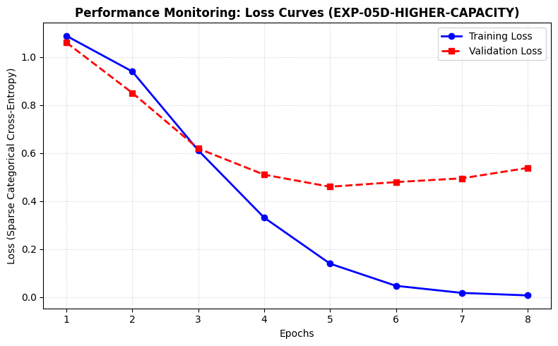

## EXP-05E-MORE-DROPOUT: EXP-05C + Increased Dropout

Starts from EXP-05C (expanded data + early stopping, hidden_dim=64) and changes exactly one more thing: `dropout_rate` 0.1 -> 0.3. EXP-05D already showed the remaining train/val gap isn't a capacity problem -- this tests whether it's a regularization problem instead. Directly answers Discussion Question 2 (how does `dropout_rate` affect over/underfitting).

**Run this only after the EXP-05B data-expansion cell has already executed in this session.**

**What this cell does:** Defines the hyperparameter configuration for **EXP-05E-MORE-DROPOUT** and builds the Keras model architecture from it (Pillar 1: Architecture).

**How:**

- `np.random.seed(42)` / `tf.random.set_seed(42)` are re-applied here (not just once at the top of the notebook) so this specific run's weight initialization starts from the same fixed point regardless of what earlier experiment cells already ran and consumed random state from.
- `CONFIG` bundles this run's hyperparameters: `embed_dim`=32 and `hidden_dim`=64 are Pillar 1 (Architecture); `learning_rate`=0.005, `batch_size`=32, `epochs`=20, `optimizer_type`="Adam" are Pillar 2 (Optimization); `dropout_rate`=0.3 is Pillar 3 (Regularization).
- `patience`: 3 is also set here, used by the `EarlyStopping` callback in the next cell.
- `tf.keras.backend.clear_session()` wipes any model/graph left behind by a previous cell, so re-running cells out of order can't leak weights between experiments.
- `Sequential()` + `Input(shape=(MAX_LEN,))` declares the model and forces Keras to build it immediately, so `model.summary()` later shows real shapes instead of `?`.
- `Embedding(input_dim=len(vocab), output_dim=32, mask_zero=True)` turns each integer token into a learned 32-length vector; `mask_zero=True` tells later layers to ignore `<PAD>` positions.
- `GlobalAveragePooling1D()` averages those per-token vectors into one fixed-length vector per example — the automated feature-extraction step the lecture points to.
- `Dense(64, activation='relu')` is the hidden layer doing the actual pattern learning.
- `Dropout(0.3)` randomly zeroes hidden units during training to fight overfitting.
- `Dense(num_classes, activation='softmax')` outputs a probability over the 3 sentiment classes.

**Why:** Identical to EXP-05C except `dropout_rate`: 0.1→0.3 — the only lever changed. Directly targets Discussion Question 2 (how `dropout_rate` affects over/underfitting) once early stopping and expanded data are already in place.

**What this cell does:** Builds the optimizer, compiles the model, prints its summary, trains it, and computes the validation metrics logged for **EXP-05E-MORE-DROPOUT**.

**How:**

- The `if/else` on `CONFIG["optimizer_type"]` builds either an `Adam` or `SGD` optimizer object using this run's learning rate.
- `model.compile(loss='sparse_categorical_crossentropy', optimizer=opt, metrics=['accuracy'])` — sparse categorical cross-entropy is used because the labels are plain integers (0/1/2), not one-hot vectors; `accuracy` is tracked per epoch alongside loss.
- `model.summary()` prints the layer-by-layer shape/parameter table as a sanity check before training starts.
- `EarlyStopping(monitor='val_loss', patience=CONFIG['patience'], restore_best_weights=True)` watches validation loss; if it doesn't improve for `patience` consecutive epochs, training stops and Keras rolls the model's weights back to whichever epoch had the lowest `val_loss` (not the last epoch run).
- `history = model.fit(X_train, y_train, validation_data=(X_val, y_val), epochs=..., batch_size=..., callbacks=[early_stop], verbose=1)` — this call *is* the training loop from the lecture: each epoch runs Forward Pass → Loss Calculation → Backward Pass → Weight Update over every mini-batch, then evaluates once on the validation set.
- `val_preds_probs = model.predict(X_val)` → `np.argmax(..., axis=1)` converts the softmax probability vector for each example into a single predicted class (0, 1, or 2).
- `f1_score(y_val, val_preds, average='weighted')` (plus `precision_score`/`recall_score`, same `average='weighted'`) weights each class's contribution by how many examples it has — matching what the exercise deliverables table asks for ("Final Validation Weighted F1-Score").
- `val_loss = min(history.history['val_loss'])`, **not** `[-1]` — because `restore_best_weights=True` means the model's actual weights come from the best epoch, so reporting the last epoch's logged loss would describe a model that's no longer in memory.
- The final `print(...)` writes one summary line the student copies into the Excel training log.

**Why:** This cell is where EXP-05E-MORE-DROPOUT actually learns from data — the config/architecture cell above only sets the model up; this is what produces the val loss / F1 / precision / recall numbers that get compared against the PT-P1 benchmark and against every other run in the study.

```
Model: "sequential"
```

```
┏━━━━━━━━━━━━━━━━━━━━━━━━━━━━━━━━━┳━━━━━━━━━━━━━━━━━━━━━━━━┳━━━━━━━━━━━━━━━┓
┃ Layer (type)                    ┃ Output Shape           ┃       Param # ┃
┡━━━━━━━━━━━━━━━━━━━━━━━━━━━━━━━━━╇━━━━━━━━━━━━━━━━━━━━━━━━╇━━━━━━━━━━━━━━━┩
│ embedding (Embedding)           │ (None, 20, 32)         │        32,000 │
├─────────────────────────────────┼────────────────────────┼───────────────┤
│ global_average_pooling1d        │ (None, 32)             │             0 │
│ (GlobalAveragePooling1D)        │                        │               │
├─────────────────────────────────┼────────────────────────┼───────────────┤
│ dense (Dense)                   │ (None, 64)             │         2,112 │
├─────────────────────────────────┼────────────────────────┼───────────────┤
│ dropout (Dropout)               │ (None, 64)             │             0 │
├─────────────────────────────────┼────────────────────────┼───────────────┤
│ dense_1 (Dense)                 │ (None, 3)              │           195 │
└─────────────────────────────────┴────────────────────────┴───────────────┘
```

```
 Total params: 34,307 (134.01 KB)
```

```
 Trainable params: 34,307 (134.01 KB)
```

```
 Non-trainable params: 0 (0.00 B)
```

```
--- Starting Training Run: EXP-05E-MORE-DROPOUT ---
10/10 ━━━━━━━━━━━━━━━━━━━━ 2s 47ms/step - accuracy: 0.3259 - loss: 1.0912 - val_accuracy: 0.2941 - val_loss: 1.0766
10/10 ━━━━━━━━━━━━━━━━━━━━ 0s 18ms/step - accuracy: 0.6013 - loss: 0.9978 - val_accuracy: 0.5147 - val_loss: 0.9687
10/10 ━━━━━━━━━━━━━━━━━━━━ 0s 18ms/step - accuracy: 0.7627 - loss: 0.7694 - val_accuracy: 0.6324 - val_loss: 0.7808
10/10 ━━━━━━━━━━━━━━━━━━━━ 0s 15ms/step - accuracy: 0.9272 - loss: 0.4697 - val_accuracy: 0.7941 - val_loss: 0.5942
10/10 ━━━━━━━━━━━━━━━━━━━━ 0s 14ms/step - accuracy: 0.9715 - loss: 0.2269 - val_accuracy: 0.8235 - val_loss: 0.4704
10/10 ━━━━━━━━━━━━━━━━━━━━ 0s 19ms/step - accuracy: 0.9873 - loss: 0.0872 - val_accuracy: 0.8382 - val_loss: 0.4426
10/10 ━━━━━━━━━━━━━━━━━━━━ 0s 16ms/step - accuracy: 0.9968 - loss: 0.0347 - val_accuracy: 0.8235 - val_loss: 0.4630
10/10 ━━━━━━━━━━━━━━━━━━━━ 0s 14ms/step - accuracy: 1.0000 - loss: 0.0133 - val_accuracy: 0.8235 - val_loss: 0.4917
10/10 ━━━━━━━━━━━━━━━━━━━━ 0s 20ms/step - accuracy: 1.0000 - loss: 0.0077 - val_accuracy: 0.8088 - val_loss: 0.5367
Epoch 9: early stopping
Restoring model weights from the end of the best epoch: 6.
3/3 ━━━━━━━━━━━━━━━━━━━━ 0s 59ms/step

=== EXP LOG ENTRY ===
ID: EXP-05E-MORE-DROPOUT | LR: 0.005 | Hidden: 64 | Dropout: 0.3 | Epochs Trained: 9/20 | Final Val Loss: 0.4426 | Final Val F1: 0.8376 | Final Val Precision: 0.8405 | Final Val Recall: 0.8382
```

**What this cell does:** Plots training loss vs. validation loss per epoch for **EXP-05E-MORE-DROPOUT** and saves the figure to Drive.

**How:**

- `train_losses`/`val_losses` are pulled straight from `history.history`, the per-epoch log Keras kept during `.fit()` in the previous cell.
- `epochs_range = range(1, len(train_losses) + 1)` — uses the *actual* number of epochs completed (`len(train_losses)`), not `CONFIG['epochs']`, because EarlyStopping may have halted training before reaching the configured cap.
- Two lines are plotted on the same axes: training loss (blue, solid, circle markers) and validation loss (red, dashed, square markers) — putting both on one chart is what makes over/underfitting visually obvious, per the lecture's "Diagnosing Model Fit" slide (converging together = good fit, diverging = overfitting, both flat and high = underfitting).
- `plt.savefig(f'{SAVE_DIR}/{CONFIG["run_id"]}_loss_curve.png', ...)` writes a uniquely-named PNG for this run into the shared `loss_curves` Drive folder *before* `plt.show()` displays it inline, so every run's chart survives after the session ends.

**Why:** Task 3 explicitly requires saving a copy of each experiment's loss curve for the report, and this is the artifact used to classify EXP-05E-MORE-DROPOUT as underfitting, overfitting, or a good fit when writing up Discussion Question 2.

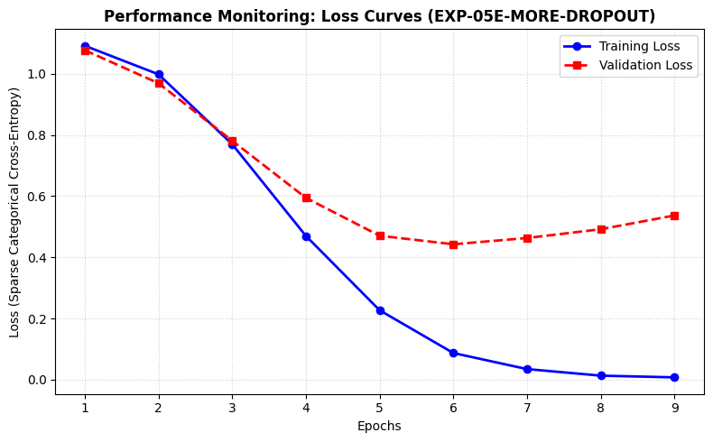

## EXP-05F-LR-SCHEDULE: EXP-05C + Cosine Learning-Rate Decay

Starts from EXP-05C and replaces the flat learning rate with a cosine decay schedule -- every single run so far, including all of EXP-01 through EXP-05D, used a constant LR. The lecture (Pillar 2) specifically calls out schedules as improving training stability; this is the one lever from that section nothing has tested yet.

**Run this only after the EXP-05B data-expansion cell has already executed in this session.**

**What this cell does:** Defines the hyperparameter configuration for **EXP-05F-LR-SCHEDULE** and builds the Keras model architecture from it (Pillar 1: Architecture).

**How:**

- `np.random.seed(42)` / `tf.random.set_seed(42)` are re-applied here (not just once at the top of the notebook) so this specific run's weight initialization starts from the same fixed point regardless of what earlier experiment cells already ran and consumed random state from.
- `CONFIG` bundles this run's hyperparameters: `embed_dim`=32 and `hidden_dim`=64 are Pillar 1 (Architecture); `initial_learning_rate`=0.005, `batch_size`=32, `epochs`=20, `optimizer_type`="Adam" are Pillar 2 (Optimization); `dropout_rate`=0.1 is Pillar 3 (Regularization).
- `patience`: 3 is also set here, used by the `EarlyStopping` callback in the next cell.
- `tf.keras.backend.clear_session()` wipes any model/graph left behind by a previous cell, so re-running cells out of order can't leak weights between experiments.
- `Sequential()` + `Input(shape=(MAX_LEN,))` declares the model and forces Keras to build it immediately, so `model.summary()` later shows real shapes instead of `?`.
- `Embedding(input_dim=len(vocab), output_dim=32, mask_zero=True)` turns each integer token into a learned 32-length vector; `mask_zero=True` tells later layers to ignore `<PAD>` positions.
- `GlobalAveragePooling1D()` averages those per-token vectors into one fixed-length vector per example — the automated feature-extraction step the lecture points to.
- `Dense(64, activation='relu')` is the hidden layer doing the actual pattern learning.
- `Dropout(0.1)` randomly zeroes hidden units during training to fight overfitting.
- `Dense(num_classes, activation='softmax')` outputs a probability over the 3 sentiment classes.

**Why:** Same architecture as EXP-05C; the optimizer cell below replaces the flat learning rate with a cosine-decay schedule instead. Every prior run (EXP-01 through EXP-05D) used a constant LR the whole time — the lecture's Optimization pillar specifically calls out LR schedules as a stability lever nothing else here has tested yet.

**What this cell does:** Builds the optimizer, compiles the model, prints its summary, trains it, and computes the validation metrics logged for **EXP-05F-LR-SCHEDULE**.

**How:**

- The `if/else` on `CONFIG["optimizer_type"]` builds either an `Adam` or `SGD` optimizer object using this run's learning rate.
- The optimizer's learning rate is a `CosineDecay` schedule instead of a flat number: it starts at `initial_learning_rate` and smoothly decays toward 5% of that value (`alpha=0.05`) over the full training run, computed from `steps_per_epoch × epochs`.
- `model.compile(loss='sparse_categorical_crossentropy', optimizer=opt, metrics=['accuracy'])` — sparse categorical cross-entropy is used because the labels are plain integers (0/1/2), not one-hot vectors; `accuracy` is tracked per epoch alongside loss.
- `model.summary()` prints the layer-by-layer shape/parameter table as a sanity check before training starts.
- `EarlyStopping(monitor='val_loss', patience=CONFIG['patience'], restore_best_weights=True)` watches validation loss; if it doesn't improve for `patience` consecutive epochs, training stops and Keras rolls the model's weights back to whichever epoch had the lowest `val_loss` (not the last epoch run).
- `history = model.fit(X_train, y_train, validation_data=(X_val, y_val), epochs=..., batch_size=..., callbacks=[early_stop], verbose=1)` — this call *is* the training loop from the lecture: each epoch runs Forward Pass → Loss Calculation → Backward Pass → Weight Update over every mini-batch, then evaluates once on the validation set.
- `val_preds_probs = model.predict(X_val)` → `np.argmax(..., axis=1)` converts the softmax probability vector for each example into a single predicted class (0, 1, or 2).
- `f1_score(y_val, val_preds, average='weighted')` (plus `precision_score`/`recall_score`, same `average='weighted'`) weights each class's contribution by how many examples it has — matching what the exercise deliverables table asks for ("Final Validation Weighted F1-Score").
- `val_loss = min(history.history['val_loss'])`, **not** `[-1]` — because `restore_best_weights=True` means the model's actual weights come from the best epoch, so reporting the last epoch's logged loss would describe a model that's no longer in memory.
- The final `print(...)` writes one summary line the student copies into the Excel training log.

**Why:** This cell is where EXP-05F-LR-SCHEDULE actually learns from data — the config/architecture cell above only sets the model up; this is what produces the val loss / F1 / precision / recall numbers that get compared against the PT-P1 benchmark and against every other run in the study.

```
Model: "sequential"
```

```
┏━━━━━━━━━━━━━━━━━━━━━━━━━━━━━━━━━┳━━━━━━━━━━━━━━━━━━━━━━━━┳━━━━━━━━━━━━━━━┓
┃ Layer (type)                    ┃ Output Shape           ┃       Param # ┃
┡━━━━━━━━━━━━━━━━━━━━━━━━━━━━━━━━━╇━━━━━━━━━━━━━━━━━━━━━━━━╇━━━━━━━━━━━━━━━┩
│ embedding (Embedding)           │ (None, 20, 32)         │        32,000 │
├─────────────────────────────────┼────────────────────────┼───────────────┤
│ global_average_pooling1d        │ (None, 32)             │             0 │
│ (GlobalAveragePooling1D)        │                        │               │
├─────────────────────────────────┼────────────────────────┼───────────────┤
│ dense (Dense)                   │ (None, 64)             │         2,112 │
├─────────────────────────────────┼────────────────────────┼───────────────┤
│ dropout (Dropout)               │ (None, 64)             │             0 │
├─────────────────────────────────┼────────────────────────┼───────────────┤
│ dense_1 (Dense)                 │ (None, 3)              │           195 │
└─────────────────────────────────┴────────────────────────┴───────────────┘
```

```
 Total params: 34,307 (134.01 KB)
```

```
 Trainable params: 34,307 (134.01 KB)
```

```
 Non-trainable params: 0 (0.00 B)
```

```
--- Starting Training Run: EXP-05F-LR-SCHEDULE ---
10/10 ━━━━━━━━━━━━━━━━━━━━ 1s 31ms/step - accuracy: 0.4557 - loss: 1.0816 - val_accuracy: 0.4559 - val_loss: 1.0493
10/10 ━━━━━━━━━━━━━━━━━━━━ 0s 10ms/step - accuracy: 0.7753 - loss: 0.9353 - val_accuracy: 0.6029 - val_loss: 0.8935
10/10 ━━━━━━━━━━━━━━━━━━━━ 0s 10ms/step - accuracy: 0.8734 - loss: 0.6396 - val_accuracy: 0.7206 - val_loss: 0.6801
10/10 ━━━━━━━━━━━━━━━━━━━━ 0s 12ms/step - accuracy: 0.9525 - loss: 0.3519 - val_accuracy: 0.8235 - val_loss: 0.5226
10/10 ━━━━━━━━━━━━━━━━━━━━ 0s 10ms/step - accuracy: 0.9810 - loss: 0.1600 - val_accuracy: 0.8382 - val_loss: 0.4497
10/10 ━━━━━━━━━━━━━━━━━━━━ 0s 10ms/step - accuracy: 0.9905 - loss: 0.0692 - val_accuracy: 0.8382 - val_loss: 0.4388
10/10 ━━━━━━━━━━━━━━━━━━━━ 0s 10ms/step - accuracy: 1.0000 - loss: 0.0287 - val_accuracy: 0.8235 - val_loss: 0.4491
10/10 ━━━━━━━━━━━━━━━━━━━━ 0s 9ms/step - accuracy: 1.0000 - loss: 0.0160 - val_accuracy: 0.8088 - val_loss: 0.4766
10/10 ━━━━━━━━━━━━━━━━━━━━ 0s 10ms/step - accuracy: 1.0000 - loss: 0.0100 - val_accuracy: 0.8088 - val_loss: 0.4965
Epoch 9: early stopping
Restoring model weights from the end of the best epoch: 6.
3/3 ━━━━━━━━━━━━━━━━━━━━ 0s 42ms/step

=== EXP LOG ENTRY ===
ID: EXP-05F-LR-SCHEDULE | Initial LR: 0.005 (cosine decay) | Hidden: 64 | Dropout: 0.1 | Epochs Trained: 9/20 | Final Val Loss: 0.4388 | Final Val F1: 0.8390 | Final Val Precision: 0.8432 | Final Val Recall: 0.8382
```

**What this cell does:** Plots training loss vs. validation loss per epoch for **EXP-05F-LR-SCHEDULE** and saves the figure to Drive.

**How:**

- `train_losses`/`val_losses` are pulled straight from `history.history`, the per-epoch log Keras kept during `.fit()` in the previous cell.
- `epochs_range = range(1, len(train_losses) + 1)` — uses the *actual* number of epochs completed (`len(train_losses)`), not `CONFIG['epochs']`, because EarlyStopping may have halted training before reaching the configured cap.
- Two lines are plotted on the same axes: training loss (blue, solid, circle markers) and validation loss (red, dashed, square markers) — putting both on one chart is what makes over/underfitting visually obvious, per the lecture's "Diagnosing Model Fit" slide (converging together = good fit, diverging = overfitting, both flat and high = underfitting).
- `plt.savefig(f'{SAVE_DIR}/{CONFIG["run_id"]}_loss_curve.png', ...)` writes a uniquely-named PNG for this run into the shared `loss_curves` Drive folder *before* `plt.show()` displays it inline, so every run's chart survives after the session ends.

**Why:** Task 3 explicitly requires saving a copy of each experiment's loss curve for the report, and this is the artifact used to classify EXP-05F-LR-SCHEDULE as underfitting, overfitting, or a good fit when writing up Discussion Question 2.

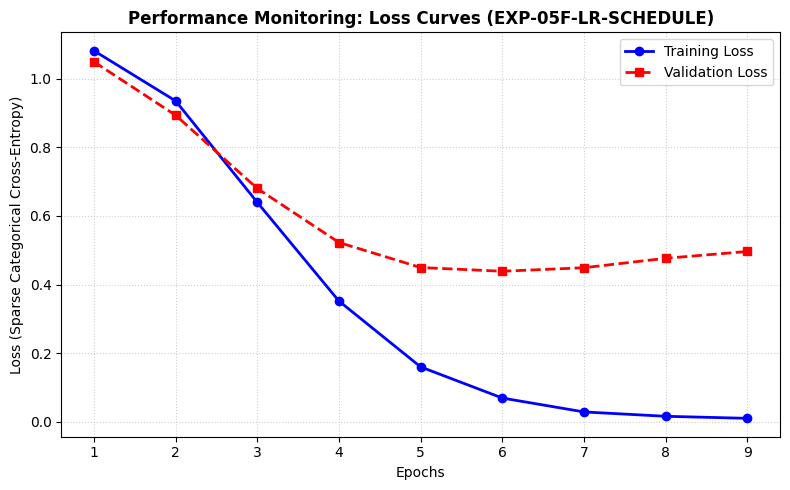

## EXP-05G-LARGER-VOCAB: EXP-05C + Increased MAX_VOCAB_SIZE

A quick check on the expanded (452-row) dataset found **1,377 unique word forms**, but `MAX_VOCAB_SIZE=1000` only keeps the top 998 (reserving 2 for `<PAD>`/`<UNK>`) -- meaning **379 unique words (about 27%) are currently collapsed into `<UNK>`** every time they appear. This tests whether recovering that lost vocabulary signal improves the model.

**Run this only after the EXP-05B data-expansion cell has already executed in this session** -- this cell reuses `df_combined` (built there) rather than reloading data.

**What this cell does:** Rebuilds the vocabulary for `EXP-05G` with a higher size cap, to recover word coverage that was previously being lost.

**How:**

- `MAX_VOCAB_SIZE_V2 = 1500` replaces the original 1000-word cap.
- `vocab_before_size` records the old vocab size purely so the printed comparison line is informative.
- `build_vocab` / `text_to_sequence` / `train_test_split` are re-run on `df_combined` (the expanded dataset built by the `EXP-05B` data-expansion cell above), overwriting `vocab`/`X_data`/etc. again with the larger-vocabulary version.

**Why:** A quick audit of the expanded (452-row) dataset found **1,377 unique word forms**, but the old `MAX_VOCAB_SIZE=1000` only keeps the top 998 words (2 slots reserved for `<PAD>`/`<UNK>`) — meaning roughly 27% of unique words were being silently collapsed into `<UNK>` every time they appeared, discarding real signal. This cell tests whether recovering that lost vocabulary improves the model.

```
Vocabulary size: 1000 (MAX_VOCAB_SIZE=1000) -> 1379 (MAX_VOCAB_SIZE_V2=1500)
New split sizes -- Train: 316, Val: 68, Test: 68
```

**What this cell does:** Defines the hyperparameter configuration for **EXP-05G-LARGER-VOCAB** and builds the Keras model architecture from it (Pillar 1: Architecture).

**How:**

- `np.random.seed(42)` / `tf.random.set_seed(42)` are re-applied here (not just once at the top of the notebook) so this specific run's weight initialization starts from the same fixed point regardless of what earlier experiment cells already ran and consumed random state from.
- `CONFIG` bundles this run's hyperparameters: `embed_dim`=32 and `hidden_dim`=64 are Pillar 1 (Architecture); `learning_rate`=0.005, `batch_size`=32, `epochs`=20, `optimizer_type`="Adam" are Pillar 2 (Optimization); `dropout_rate`=0.1 is Pillar 3 (Regularization).
- `patience`: 3 is also set here, used by the `EarlyStopping` callback in the next cell.
- `tf.keras.backend.clear_session()` wipes any model/graph left behind by a previous cell, so re-running cells out of order can't leak weights between experiments.
- `Sequential()` + `Input(shape=(MAX_LEN,))` declares the model and forces Keras to build it immediately, so `model.summary()` later shows real shapes instead of `?`.
- `Embedding(input_dim=len(vocab), output_dim=32, mask_zero=True)` turns each integer token into a learned 32-length vector; `mask_zero=True` tells later layers to ignore `<PAD>` positions.
- `GlobalAveragePooling1D()` averages those per-token vectors into one fixed-length vector per example — the automated feature-extraction step the lecture points to.
- `Dense(64, activation='relu')` is the hidden layer doing the actual pattern learning.
- `Dropout(0.1)` randomly zeroes hidden units during training to fight overfitting.
- `Dense(num_classes, activation='softmax')` outputs a probability over the 3 sentiment classes.

**Why:** Same architecture and hyperparameters as EXP-05C; the only change (made in the cell above) is rebuilding the vocabulary with a higher cap so fewer real words get collapsed into `<UNK>`.

**What this cell does:** Builds the optimizer, compiles the model, prints its summary, trains it, and computes the validation metrics logged for **EXP-05G-LARGER-VOCAB**.

**How:**

- The `if/else` on `CONFIG["optimizer_type"]` builds either an `Adam` or `SGD` optimizer object using this run's learning rate.
- `model.compile(loss='sparse_categorical_crossentropy', optimizer=opt, metrics=['accuracy'])` — sparse categorical cross-entropy is used because the labels are plain integers (0/1/2), not one-hot vectors; `accuracy` is tracked per epoch alongside loss.
- `model.summary()` prints the layer-by-layer shape/parameter table as a sanity check before training starts.
- `EarlyStopping(monitor='val_loss', patience=CONFIG['patience'], restore_best_weights=True)` watches validation loss; if it doesn't improve for `patience` consecutive epochs, training stops and Keras rolls the model's weights back to whichever epoch had the lowest `val_loss` (not the last epoch run).
- `history = model.fit(X_train, y_train, validation_data=(X_val, y_val), epochs=..., batch_size=..., callbacks=[early_stop], verbose=1)` — this call *is* the training loop from the lecture: each epoch runs Forward Pass → Loss Calculation → Backward Pass → Weight Update over every mini-batch, then evaluates once on the validation set.
- `val_preds_probs = model.predict(X_val)` → `np.argmax(..., axis=1)` converts the softmax probability vector for each example into a single predicted class (0, 1, or 2).
- `f1_score(y_val, val_preds, average='weighted')` (plus `precision_score`/`recall_score`, same `average='weighted'`) weights each class's contribution by how many examples it has — matching what the exercise deliverables table asks for ("Final Validation Weighted F1-Score").
- `val_loss = min(history.history['val_loss'])`, **not** `[-1]` — because `restore_best_weights=True` means the model's actual weights come from the best epoch, so reporting the last epoch's logged loss would describe a model that's no longer in memory.
- The final `print(...)` writes one summary line the student copies into the Excel training log.

**Why:** This cell is where EXP-05G-LARGER-VOCAB actually learns from data — the config/architecture cell above only sets the model up; this is what produces the val loss / F1 / precision / recall numbers that get compared against the PT-P1 benchmark and against every other run in the study.

```
Model: "sequential"
```

```
┏━━━━━━━━━━━━━━━━━━━━━━━━━━━━━━━━━┳━━━━━━━━━━━━━━━━━━━━━━━━┳━━━━━━━━━━━━━━━┓
┃ Layer (type)                    ┃ Output Shape           ┃       Param # ┃
┡━━━━━━━━━━━━━━━━━━━━━━━━━━━━━━━━━╇━━━━━━━━━━━━━━━━━━━━━━━━╇━━━━━━━━━━━━━━━┩
│ embedding (Embedding)           │ (None, 20, 32)         │        44,128 │
├─────────────────────────────────┼────────────────────────┼───────────────┤
│ global_average_pooling1d        │ (None, 32)             │             0 │
│ (GlobalAveragePooling1D)        │                        │               │
├─────────────────────────────────┼────────────────────────┼───────────────┤
│ dense (Dense)                   │ (None, 64)             │         2,112 │
├─────────────────────────────────┼────────────────────────┼───────────────┤
│ dropout (Dropout)               │ (None, 64)             │             0 │
├─────────────────────────────────┼────────────────────────┼───────────────┤
│ dense_1 (Dense)                 │ (None, 3)              │           195 │
└─────────────────────────────────┴────────────────────────┴───────────────┘
```

```
 Total params: 46,435 (181.39 KB)
```

```
 Trainable params: 46,435 (181.39 KB)
```

```
 Non-trainable params: 0 (0.00 B)
```

```
--- Starting Training Run: EXP-05G-LARGER-VOCAB ---
10/10 ━━━━━━━━━━━━━━━━━━━━ 1s 31ms/step - accuracy: 0.4652 - loss: 1.0884 - val_accuracy: 0.5588 - val_loss: 1.0643
10/10 ━━━━━━━━━━━━━━━━━━━━ 0s 10ms/step - accuracy: 0.9335 - loss: 0.9630 - val_accuracy: 0.8088 - val_loss: 0.9087
10/10 ━━━━━━━━━━━━━━━━━━━━ 0s 10ms/step - accuracy: 0.9715 - loss: 0.6522 - val_accuracy: 0.8235 - val_loss: 0.6540
10/10 ━━━━━━━━━━━━━━━━━━━━ 0s 10ms/step - accuracy: 0.9842 - loss: 0.2829 - val_accuracy: 0.8235 - val_loss: 0.4783
10/10 ━━━━━━━━━━━━━━━━━━━━ 0s 10ms/step - accuracy: 0.9968 - loss: 0.0820 - val_accuracy: 0.8382 - val_loss: 0.4288
10/10 ━━━━━━━━━━━━━━━━━━━━ 0s 11ms/step - accuracy: 1.0000 - loss: 0.0231 - val_accuracy: 0.8382 - val_loss: 0.4531
10/10 ━━━━━━━━━━━━━━━━━━━━ 0s 10ms/step - accuracy: 1.0000 - loss: 0.0076 - val_accuracy: 0.8382 - val_loss: 0.4846
10/10 ━━━━━━━━━━━━━━━━━━━━ 0s 10ms/step - accuracy: 1.0000 - loss: 0.0039 - val_accuracy: 0.8235 - val_loss: 0.5133
Epoch 8: early stopping
Restoring model weights from the end of the best epoch: 5.
3/3 ━━━━━━━━━━━━━━━━━━━━ 0s 37ms/step

=== EXP LOG ENTRY ===
ID: EXP-05G-LARGER-VOCAB | LR: 0.005 | Hidden: 64 | Dropout: 0.1 | Epochs Trained: 8/20 | Final Val Loss: 0.4288 | Final Val F1: 0.8407 | Final Val Precision: 0.8474 | Final Val Recall: 0.8382
```

**What this cell does:** Plots training loss vs. validation loss per epoch for **EXP-05G-LARGER-VOCAB** and saves the figure to Drive.

**How:**

- `train_losses`/`val_losses` are pulled straight from `history.history`, the per-epoch log Keras kept during `.fit()` in the previous cell.
- `epochs_range = range(1, len(train_losses) + 1)` — uses the *actual* number of epochs completed (`len(train_losses)`), not `CONFIG['epochs']`, because EarlyStopping may have halted training before reaching the configured cap.
- Two lines are plotted on the same axes: training loss (blue, solid, circle markers) and validation loss (red, dashed, square markers) — putting both on one chart is what makes over/underfitting visually obvious, per the lecture's "Diagnosing Model Fit" slide (converging together = good fit, diverging = overfitting, both flat and high = underfitting).
- `plt.savefig(f'{SAVE_DIR}/{CONFIG["run_id"]}_loss_curve.png', ...)` writes a uniquely-named PNG for this run into the shared `loss_curves` Drive folder *before* `plt.show()` displays it inline, so every run's chart survives after the session ends.

**Why:** Task 3 explicitly requires saving a copy of each experiment's loss curve for the report, and this is the artifact used to classify EXP-05G-LARGER-VOCAB as underfitting, overfitting, or a good fit when writing up Discussion Question 2.

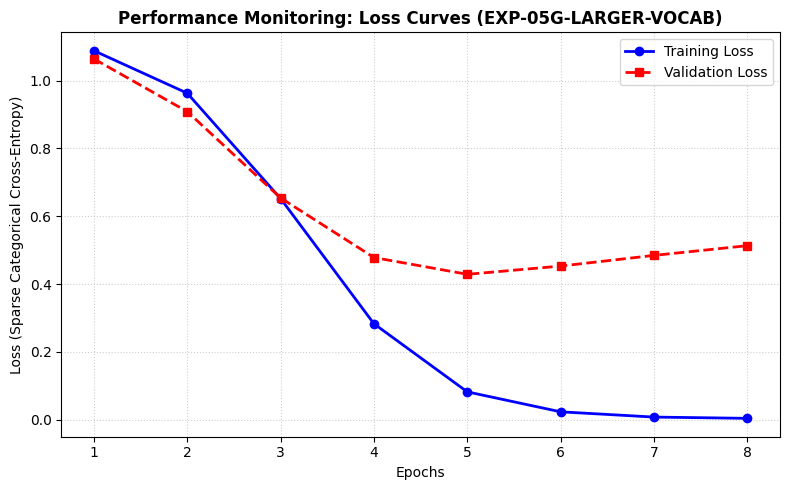

## EXP-05H-SGD-OPTIMIZER: EXP-05C + SGD Optimizer (Isolate Optimizer Choice)

**What this cell does:** Defines the hyperparameter configuration for **EXP-05H-SGD-OPTIMIZER** and builds the Keras model architecture from it (Pillar 1: Architecture).

**How:**

- `np.random.seed(42)` / `tf.random.set_seed(42)` are re-applied here (not just once at the top of the notebook) so this specific run's weight initialization starts from the same fixed point regardless of what earlier experiment cells already ran and consumed random state from.
- `CONFIG` bundles this run's hyperparameters: `embed_dim`=32 and `hidden_dim`=64 are Pillar 1 (Architecture); `learning_rate`=0.005, `batch_size`=32, `epochs`=20, `optimizer_type`="SGD" are Pillar 2 (Optimization); `dropout_rate`=0.1 is Pillar 3 (Regularization).
- `patience`: 3 is also set here, used by the `EarlyStopping` callback in the next cell.
- `tf.keras.backend.clear_session()` wipes any model/graph left behind by a previous cell, so re-running cells out of order can't leak weights between experiments.
- `Sequential()` + `Input(shape=(MAX_LEN,))` declares the model and forces Keras to build it immediately, so `model.summary()` later shows real shapes instead of `?`.
- `Embedding(input_dim=len(vocab), output_dim=32, mask_zero=True)` turns each integer token into a learned 32-length vector; `mask_zero=True` tells later layers to ignore `<PAD>` positions.
- `GlobalAveragePooling1D()` averages those per-token vectors into one fixed-length vector per example — the automated feature-extraction step the lecture points to.
- `Dense(64, activation='relu')` is the hidden layer doing the actual pattern learning.
- `Dropout(0.1)` randomly zeroes hidden units during training to fight overfitting.
- `Dense(num_classes, activation='softmax')` outputs a probability over the 3 sentiment classes.

**What this cell does:** Builds the optimizer, compiles the model, prints its summary, trains it, and computes the validation metrics logged for **EXP-05H-SGD-OPTIMIZER**.

**How:**

- The `if/else` on `CONFIG["optimizer_type"]` builds either an `Adam` or `SGD` optimizer object using this run's learning rate.
- `model.compile(loss='sparse_categorical_crossentropy', optimizer=opt, metrics=['accuracy'])` — sparse categorical cross-entropy is used because the labels are plain integers (0/1/2), not one-hot vectors; `accuracy` is tracked per epoch alongside loss.
- `model.summary()` prints the layer-by-layer shape/parameter table as a sanity check before training starts.
- `EarlyStopping(monitor='val_loss', patience=CONFIG['patience'], restore_best_weights=True)` watches validation loss; if it doesn't improve for `patience` consecutive epochs, training stops and Keras rolls the model's weights back to whichever epoch had the lowest `val_loss` (not the last epoch run).
- `history = model.fit(X_train, y_train, validation_data=(X_val, y_val), epochs=..., batch_size=..., callbacks=[early_stop], verbose=1)` — this call *is* the training loop from the lecture: each epoch runs Forward Pass → Loss Calculation → Backward Pass → Weight Update over every mini-batch, then evaluates once on the validation set.
- `val_preds_probs = model.predict(X_val)` → `np.argmax(..., axis=1)` converts the softmax probability vector for each example into a single predicted class (0, 1, or 2).
- `f1_score(y_val, val_preds, average='weighted')` (plus `precision_score`/`recall_score`, same `average='weighted'`) weights each class's contribution by how many examples it has — matching what the exercise deliverables table asks for ("Final Validation Weighted F1-Score").
- `val_loss = min(history.history['val_loss'])`, **not** `[-1]` — because `restore_best_weights=True` means the model's actual weights come from the best epoch, so reporting the last epoch's logged loss would describe a model that's no longer in memory.
- The final `print(...)` writes one summary line the student copies into the Excel training log.

**Why:** This cell is where EXP-05H-SGD-OPTIMIZER actually learns from data — the config/architecture cell above only sets the model up; this is what produces the val loss / F1 / precision / recall numbers that get compared against the PT-P1 benchmark and against every other run in the study.

```
Model: "sequential"
```

```
┏━━━━━━━━━━━━━━━━━━━━━━━━━━━━━━━━━┳━━━━━━━━━━━━━━━━━━━━━━━━┳━━━━━━━━━━━━━━━┓
┃ Layer (type)                    ┃ Output Shape           ┃       Param # ┃
┡━━━━━━━━━━━━━━━━━━━━━━━━━━━━━━━━━╇━━━━━━━━━━━━━━━━━━━━━━━━╇━━━━━━━━━━━━━━━┩
│ embedding (Embedding)           │ (None, 20, 32)         │        44,128 │
├─────────────────────────────────┼────────────────────────┼───────────────┤
│ global_average_pooling1d        │ (None, 32)             │             0 │
│ (GlobalAveragePooling1D)        │                        │               │
├─────────────────────────────────┼────────────────────────┼───────────────┤
│ dense (Dense)                   │ (None, 64)             │         2,112 │
├─────────────────────────────────┼────────────────────────┼───────────────┤
│ dropout (Dropout)               │ (None, 64)             │             0 │
├─────────────────────────────────┼────────────────────────┼───────────────┤
│ dense_1 (Dense)                 │ (None, 3)              │           195 │
└─────────────────────────────────┴────────────────────────┴───────────────┘
```

```
 Total params: 46,435 (181.39 KB)
```

```
 Trainable params: 46,435 (181.39 KB)
```

```
 Non-trainable params: 0 (0.00 B)
```

```
--- Starting Training Run: EXP-05H-SGD-OPTIMIZER ---
10/10 ━━━━━━━━━━━━━━━━━━━━ 1s 32ms/step - accuracy: 0.3418 - loss: 1.0989 - val_accuracy: 0.4265 - val_loss: 1.0968
10/10 ━━━━━━━━━━━━━━━━━━━━ 0s 10ms/step - accuracy: 0.3449 - loss: 1.0986 - val_accuracy: 0.4118 - val_loss: 1.0969
10/10 ━━━━━━━━━━━━━━━━━━━━ 0s 9ms/step - accuracy: 0.3481 - loss: 1.0983 - val_accuracy: 0.4265 - val_loss: 1.0971
10/10 ━━━━━━━━━━━━━━━━━━━━ 0s 13ms/step - accuracy: 0.3513 - loss: 1.0981 - val_accuracy: 0.4412 - val_loss: 1.0973
Epoch 4: early stopping
Restoring model weights from the end of the best epoch: 1.
3/3 ━━━━━━━━━━━━━━━━━━━━ 0s 56ms/step

=== EXP LOG ENTRY ===
ID: EXP-05H-SGD-OPTIMIZER | Optimizer: SGD | LR: 0.005 | Hidden: 64 | Dropout: 0.1 | Epochs Trained: 4/20 | Final Val Loss: 1.0968 | Final Val F1: 0.4184 | Final Val Precision: 0.4195 | Final Val Recall: 0.4265
```

**What this cell does:** Plots training loss vs. validation loss per epoch for **EXP-05H-SGD-OPTIMIZER** and saves the figure to Drive.

**How:**

- `train_losses`/`val_losses` are pulled straight from `history.history`, the per-epoch log Keras kept during `.fit()` in the previous cell.
- `epochs_range = range(1, len(train_losses) + 1)` — uses the *actual* number of epochs completed (`len(train_losses)`), not `CONFIG['epochs']`, because EarlyStopping may have halted training before reaching the configured cap.
- Two lines are plotted on the same axes: training loss (blue, solid, circle markers) and validation loss (red, dashed, square markers) — putting both on one chart is what makes over/underfitting visually obvious, per the lecture's "Diagnosing Model Fit" slide (converging together = good fit, diverging = overfitting, both flat and high = underfitting).
- `plt.savefig(f'{SAVE_DIR}/{CONFIG["run_id"]}_loss_curve.png', ...)` writes a uniquely-named PNG for this run into the shared `loss_curves` Drive folder *before* `plt.show()` displays it inline, so every run's chart survives after the session ends.

**Why:** Task 3 explicitly requires saving a copy of each experiment's loss curve for the report, and this is the artifact used to classify EXP-05H-SGD-OPTIMIZER as underfitting, overfitting, or a good fit when writing up Discussion Question 2.

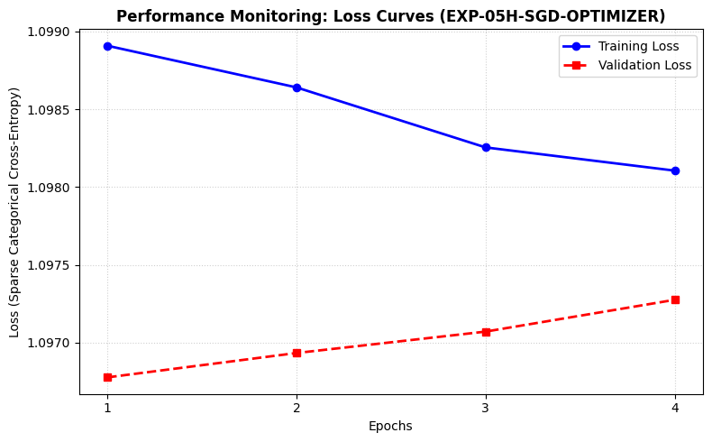

## EXP-05I-CAPACITY-ONLY: EXP-05D Architecture on Original (Non-Expanded) Data

Same architecture and hyperparameters as EXP-05D (hidden_dim 128, early stopping), but trained on the original dataset instead of the expanded one, to see how much of EXP-05D's performance came from capacity alone versus capacity + more data. **Self-contained**: this cell reloads and re-encodes the original CSV directly rather than relying on global state left behind by earlier cells, so it can be run on its own without executing EXP-05B/05C/etc. first (only the very first setup cell -- imports, Drive mount -- needs to have run).

**What this cell does:** For `EXP-05I`, reloads the **original, non-expanded** dataset directly from disk (rather than trusting whatever an earlier cell left in memory), then defines this run's hyperparameters and architecture.

**How:**

- `_df_original_only` is a deliberately distinct, locally-scoped variable name (not `df_original`, which an earlier cell also defines) so this cell can't accidentally depend on state left behind by `EXP-05B`/`EXP-05C`/etc.
- `build_vocab` / `text_to_sequence` / `train_test_split` are re-run on `_df_original_only`, producing a fresh `vocab`, `X_train`, `X_val`, etc. based only on the original 332-row dataset.
- The `CONFIG`/architecture section below matches `EXP-05D` exactly (`hidden_dim: 128`, early stopping via `patience`) — the *only* thing different from `EXP-05D` is which dataset was used to build `X_train`/`X_val` above.

**Why:** This run exists specifically to isolate one variable: how much of `EXP-05D`'s result came from the capacity increase (`hidden_dim` 64→128) alone, versus capacity *combined with* the expanded dataset. Making the cell self-contained (only requiring the very first setup cell to have run) is what makes that isolation trustworthy — it can't silently inherit the expanded dataset from an earlier cell in the session.

```
Original dataset -- Train: 232, Val: 50, Test: 50
Vocabulary size: 1000
```

**What this cell does:** Builds the optimizer, compiles the model, prints its summary, trains it, and computes the validation metrics logged for **EXP-05I-CAPACITY-ONLY**.

**How:**

- The `if/else` on `CONFIG["optimizer_type"]` builds either an `Adam` or `SGD` optimizer object using this run's learning rate.
- `model.compile(loss='sparse_categorical_crossentropy', optimizer=opt, metrics=['accuracy'])` — sparse categorical cross-entropy is used because the labels are plain integers (0/1/2), not one-hot vectors; `accuracy` is tracked per epoch alongside loss.
- `model.summary()` prints the layer-by-layer shape/parameter table as a sanity check before training starts.
- `EarlyStopping(monitor='val_loss', patience=CONFIG['patience'], restore_best_weights=True)` watches validation loss; if it doesn't improve for `patience` consecutive epochs, training stops and Keras rolls the model's weights back to whichever epoch had the lowest `val_loss` (not the last epoch run).
- `history = model.fit(X_train, y_train, validation_data=(X_val, y_val), epochs=..., batch_size=..., callbacks=[early_stop], verbose=1)` — this call *is* the training loop from the lecture: each epoch runs Forward Pass → Loss Calculation → Backward Pass → Weight Update over every mini-batch, then evaluates once on the validation set.
- `val_preds_probs = model.predict(X_val)` → `np.argmax(..., axis=1)` converts the softmax probability vector for each example into a single predicted class (0, 1, or 2).
- `f1_score(y_val, val_preds, average='weighted')` (plus `precision_score`/`recall_score`, same `average='weighted'`) weights each class's contribution by how many examples it has — matching what the exercise deliverables table asks for ("Final Validation Weighted F1-Score").
- `val_loss = min(history.history['val_loss'])`, **not** `[-1]` — because `restore_best_weights=True` means the model's actual weights come from the best epoch, so reporting the last epoch's logged loss would describe a model that's no longer in memory.
- The final `print(...)` writes one summary line the student copies into the Excel training log.

**Why:** This cell is where EXP-05I-CAPACITY-ONLY actually learns from data — the config/architecture cell above only sets the model up; this is what produces the val loss / F1 / precision / recall numbers that get compared against the PT-P1 benchmark and against every other run in the study.

```
Model: "sequential"
```

```
┏━━━━━━━━━━━━━━━━━━━━━━━━━━━━━━━━━┳━━━━━━━━━━━━━━━━━━━━━━━━┳━━━━━━━━━━━━━━━┓
┃ Layer (type)                    ┃ Output Shape           ┃       Param # ┃
┡━━━━━━━━━━━━━━━━━━━━━━━━━━━━━━━━━╇━━━━━━━━━━━━━━━━━━━━━━━━╇━━━━━━━━━━━━━━━┩
│ embedding (Embedding)           │ (None, 20, 32)         │        32,000 │
├─────────────────────────────────┼────────────────────────┼───────────────┤
│ global_average_pooling1d        │ (None, 32)             │             0 │
│ (GlobalAveragePooling1D)        │                        │               │
├─────────────────────────────────┼────────────────────────┼───────────────┤
│ dense (Dense)                   │ (None, 128)            │         4,224 │
├─────────────────────────────────┼────────────────────────┼───────────────┤
│ dropout (Dropout)               │ (None, 128)            │             0 │
├─────────────────────────────────┼────────────────────────┼───────────────┤
│ dense_1 (Dense)                 │ (None, 3)              │           387 │
└─────────────────────────────────┴────────────────────────┴───────────────┘
```

```
 Total params: 36,611 (143.01 KB)
```

```
 Trainable params: 36,611 (143.01 KB)
```

```
 Non-trainable params: 0 (0.00 B)
```

```
--- Starting Training Run: EXP-05I-CAPACITY-ONLY ---
8/8 ━━━━━━━━━━━━━━━━━━━━ 2s 60ms/step - accuracy: 0.3664 - loss: 1.0933 - val_accuracy: 0.5600 - val_loss: 1.0642
8/8 ━━━━━━━━━━━━━━━━━━━━ 0s 23ms/step - accuracy: 0.7069 - loss: 0.9688 - val_accuracy: 0.7200 - val_loss: 0.9060
8/8 ━━━━━━━━━━━━━━━━━━━━ 0s 12ms/step - accuracy: 0.9224 - loss: 0.7019 - val_accuracy: 0.7600 - val_loss: 0.6754
8/8 ━━━━━━━━━━━━━━━━━━━━ 0s 12ms/step - accuracy: 0.9698 - loss: 0.4101 - val_accuracy: 0.8000 - val_loss: 0.5067
8/8 ━━━━━━━━━━━━━━━━━━━━ 0s 14ms/step - accuracy: 0.9828 - loss: 0.1967 - val_accuracy: 0.8200 - val_loss: 0.4336
8/8 ━━━━━━━━━━━━━━━━━━━━ 0s 13ms/step - accuracy: 0.9914 - loss: 0.0681 - val_accuracy: 0.8000 - val_loss: 0.4450
8/8 ━━━━━━━━━━━━━━━━━━━━ 0s 12ms/step - accuracy: 1.0000 - loss: 0.0194 - val_accuracy: 0.7800 - val_loss: 0.4997
8/8 ━━━━━━━━━━━━━━━━━━━━ 0s 12ms/step - accuracy: 1.0000 - loss: 0.0066 - val_accuracy: 0.7800 - val_loss: 0.5504
Epoch 8: early stopping
Restoring model weights from the end of the best epoch: 5.
2/2 ━━━━━━━━━━━━━━━━━━━━ 0s 76ms/step

=== EXP LOG ENTRY ===
ID: EXP-05I-CAPACITY-ONLY | LR: 0.005 | Hidden: 128 | Dropout: 0.1 | Epochs Trained: 8/20 | Final Val Loss: 0.4336 | Final Val F1: 0.8205 | Final Val Precision: 0.8287 | Final Val Recall: 0.8200
```

**What this cell does:** Plots training loss vs. validation loss per epoch for **EXP-05I-CAPACITY-ONLY** and saves the figure to Drive.

**How:**

- `train_losses`/`val_losses` are pulled straight from `history.history`, the per-epoch log Keras kept during `.fit()` in the previous cell.
- `epochs_range = range(1, len(train_losses) + 1)` — uses the *actual* number of epochs completed (`len(train_losses)`), not `CONFIG['epochs']`, because EarlyStopping may have halted training before reaching the configured cap.
- Two lines are plotted on the same axes: training loss (blue, solid, circle markers) and validation loss (red, dashed, square markers) — putting both on one chart is what makes over/underfitting visually obvious, per the lecture's "Diagnosing Model Fit" slide (converging together = good fit, diverging = overfitting, both flat and high = underfitting).
- `plt.savefig(f'{SAVE_DIR}/{CONFIG["run_id"]}_loss_curve.png', ...)` writes a uniquely-named PNG for this run into the shared `loss_curves` Drive folder *before* `plt.show()` displays it inline, so every run's chart survives after the session ends.

**Why:** Task 3 explicitly requires saving a copy of each experiment's loss curve for the report, and this is the artifact used to classify EXP-05I-CAPACITY-ONLY as underfitting, overfitting, or a good fit when writing up Discussion Question 2.

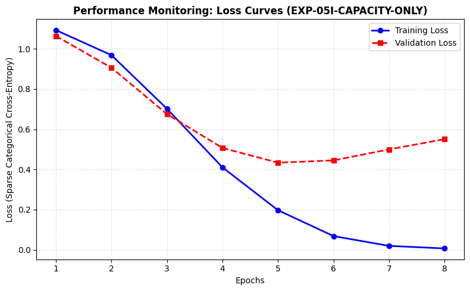

## EXP-05J-BATCH-SIZE: EXP-05C + Smaller Batch Size (Isolate Batch Size)

Same config as EXP-05C (expanded data, early stopping, hidden_dim 64, LR 0.005, dropout 0.1) but with `batch_size` dropped from 32 to 16, to isolate the batch-size lever the lecture calls out under Pillar 2 (Optimization) -- the tradeoff between gradient noise, training speed, and generalization. **Self-contained**: rebuilds the expanded dataset directly from both CSVs rather than relying on state from earlier cells.

**What this cell does:** For `EXP-05J`, rebuilds the **expanded** (original + expansion) dataset directly from both CSVs on disk, independent of any state left behind by earlier cells, then defines this run's hyperparameters and architecture.

**How:**

- `_df_orig` / `_df_exp` are read fresh from both CSV files and concatenated into `_df_combined_local` — all locally-scoped names, distinct from `df_combined` used elsewhere, so this cell can't accidentally depend on whether `EXP-05B`'s data-expansion cell already ran in this session.
- `build_vocab` / `text_to_sequence` / `train_test_split` rebuild `vocab`/`X_train`/`X_val`/etc. from that locally-built combined dataset.
- The `CONFIG`/architecture section below matches `EXP-05C` exactly except `batch_size`: 32→16.

**Why:** Like `EXP-05I`, this keeps the batch-size ablation reproducible regardless of which earlier cells were or weren't executed — the whole point of this run is to isolate the effect of one smaller lever (batch size), so it can't be allowed to depend on fragile notebook execution order.

```
Expanded dataset -- Train: 316, Val: 68, Test: 68
Vocabulary size: 1000
```

**What this cell does:** Builds the optimizer, compiles the model, prints its summary, trains it, and computes the validation metrics logged for **EXP-05J-BATCH-SIZE**.

**How:**

- The `if/else` on `CONFIG["optimizer_type"]` builds either an `Adam` or `SGD` optimizer object using this run's learning rate.
- `model.compile(loss='sparse_categorical_crossentropy', optimizer=opt, metrics=['accuracy'])` — sparse categorical cross-entropy is used because the labels are plain integers (0/1/2), not one-hot vectors; `accuracy` is tracked per epoch alongside loss.
- `model.summary()` prints the layer-by-layer shape/parameter table as a sanity check before training starts.
- `EarlyStopping(monitor='val_loss', patience=CONFIG['patience'], restore_best_weights=True)` watches validation loss; if it doesn't improve for `patience` consecutive epochs, training stops and Keras rolls the model's weights back to whichever epoch had the lowest `val_loss` (not the last epoch run).
- `history = model.fit(X_train, y_train, validation_data=(X_val, y_val), epochs=..., batch_size=..., callbacks=[early_stop], verbose=1)` — this call *is* the training loop from the lecture: each epoch runs Forward Pass → Loss Calculation → Backward Pass → Weight Update over every mini-batch, then evaluates once on the validation set.
- `val_preds_probs = model.predict(X_val)` → `np.argmax(..., axis=1)` converts the softmax probability vector for each example into a single predicted class (0, 1, or 2).
- `f1_score(y_val, val_preds, average='weighted')` (plus `precision_score`/`recall_score`, same `average='weighted'`) weights each class's contribution by how many examples it has — matching what the exercise deliverables table asks for ("Final Validation Weighted F1-Score").
- `val_loss = min(history.history['val_loss'])`, **not** `[-1]` — because `restore_best_weights=True` means the model's actual weights come from the best epoch, so reporting the last epoch's logged loss would describe a model that's no longer in memory.
- The final `print(...)` writes one summary line the student copies into the Excel training log.

**Why:** This cell is where EXP-05J-BATCH-SIZE actually learns from data — the config/architecture cell above only sets the model up; this is what produces the val loss / F1 / precision / recall numbers that get compared against the PT-P1 benchmark and against every other run in the study.

```
Model: "sequential"
```

```
┏━━━━━━━━━━━━━━━━━━━━━━━━━━━━━━━━━┳━━━━━━━━━━━━━━━━━━━━━━━━┳━━━━━━━━━━━━━━━┓
┃ Layer (type)                    ┃ Output Shape           ┃       Param # ┃
┡━━━━━━━━━━━━━━━━━━━━━━━━━━━━━━━━━╇━━━━━━━━━━━━━━━━━━━━━━━━╇━━━━━━━━━━━━━━━┩
│ embedding (Embedding)           │ (None, 20, 32)         │        32,000 │
├─────────────────────────────────┼────────────────────────┼───────────────┤
│ global_average_pooling1d        │ (None, 32)             │             0 │
│ (GlobalAveragePooling1D)        │                        │               │
├─────────────────────────────────┼────────────────────────┼───────────────┤
│ dense (Dense)                   │ (None, 64)             │         2,112 │
├─────────────────────────────────┼────────────────────────┼───────────────┤
│ dropout (Dropout)               │ (None, 64)             │             0 │
├─────────────────────────────────┼────────────────────────┼───────────────┤
│ dense_1 (Dense)                 │ (None, 3)              │           195 │
└─────────────────────────────────┴────────────────────────┴───────────────┘
```

```
 Total params: 34,307 (134.01 KB)
```

```
 Trainable params: 34,307 (134.01 KB)
```

```
 Non-trainable params: 0 (0.00 B)
```

```
--- Starting Training Run: EXP-05J-BATCH-SIZE ---
20/20 ━━━━━━━━━━━━━━━━━━━━ 1s 16ms/step - accuracy: 0.4146 - loss: 1.0721 - val_accuracy: 0.4853 - val_loss: 1.0057
20/20 ━━━━━━━━━━━━━━━━━━━━ 0s 6ms/step - accuracy: 0.8418 - loss: 0.7582 - val_accuracy: 0.7794 - val_loss: 0.6578
20/20 ━━━━━━━━━━━━━━━━━━━━ 0s 6ms/step - accuracy: 0.9620 - loss: 0.2983 - val_accuracy: 0.8235 - val_loss: 0.4626
20/20 ━━━━━━━━━━━━━━━━━━━━ 0s 6ms/step - accuracy: 0.9905 - loss: 0.0670 - val_accuracy: 0.8382 - val_loss: 0.4539
20/20 ━━━━━━━━━━━━━━━━━━━━ 0s 6ms/step - accuracy: 1.0000 - loss: 0.0164 - val_accuracy: 0.8235 - val_loss: 0.5015
20/20 ━━━━━━━━━━━━━━━━━━━━ 0s 6ms/step - accuracy: 1.0000 - loss: 0.0091 - val_accuracy: 0.8235 - val_loss: 0.5486
20/20 ━━━━━━━━━━━━━━━━━━━━ 0s 6ms/step - accuracy: 1.0000 - loss: 0.0039 - val_accuracy: 0.8088 - val_loss: 0.5725
Epoch 7: early stopping
Restoring model weights from the end of the best epoch: 4.
3/3 ━━━━━━━━━━━━━━━━━━━━ 0s 37ms/step

=== EXP LOG ENTRY ===
ID: EXP-05J-BATCH-SIZE | LR: 0.005 | Hidden: 64 | Batch Size: 16 | Dropout: 0.1 | Epochs Trained: 7/20 | Final Val Loss: 0.4539 | Final Val F1: 0.8416 | Final Val Precision: 0.8569 | Final Val Recall: 0.8382
```

**What this cell does:** Plots training loss vs. validation loss per epoch for **EXP-05J-BATCH-SIZE** and saves the figure to Drive.

**How:**

- `train_losses`/`val_losses` are pulled straight from `history.history`, the per-epoch log Keras kept during `.fit()` in the previous cell.
- `epochs_range = range(1, len(train_losses) + 1)` — uses the *actual* number of epochs completed (`len(train_losses)`), not `CONFIG['epochs']`, because EarlyStopping may have halted training before reaching the configured cap.
- Two lines are plotted on the same axes: training loss (blue, solid, circle markers) and validation loss (red, dashed, square markers) — putting both on one chart is what makes over/underfitting visually obvious, per the lecture's "Diagnosing Model Fit" slide (converging together = good fit, diverging = overfitting, both flat and high = underfitting).
- `plt.savefig(f'{SAVE_DIR}/{CONFIG["run_id"]}_loss_curve.png', ...)` writes a uniquely-named PNG for this run into the shared `loss_curves` Drive folder *before* `plt.show()` displays it inline, so every run's chart survives after the session ends.

**Why:** Task 3 explicitly requires saving a copy of each experiment's loss curve for the report, and this is the artifact used to classify EXP-05J-BATCH-SIZE as underfitting, overfitting, or a good fit when writing up Discussion Question 2.

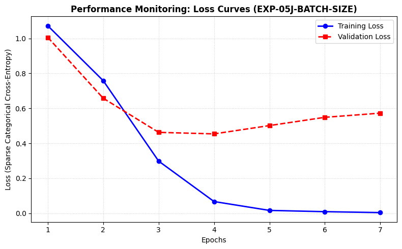